# Aprendizagem Supervisionada de Regressão em R

Pedro Almeida

17 de fevereiro de 2019

## 1) O que é uma regressão?

Na primeira parte desse código será apresentado o conceito de regressão do ponto de vista da aprendizagem de máquina. Será apresentado o método de regressão fundamental: a regressão linear. Mostrarei como ajustar um modelo de regressão linear e fazer previsões a partir do modelo.

### 1.1) Regressão linear simples

A regressão linear é uma equação que estima o valor esperado de uma variável y, dados os valores de algumas outras variáveis x (no caso de uma regressão multivariada, que será abordada mais a frente), ou dado o valor de uma única variável x (regressão linear simples).

A regressão linear é chamada “linear” pois é considerada que a relação da resposta às variáveis é uma função linear de alguns parâmetros. Os modelos de regressão que não são uma função linear dos parâmetros são chamados de modelos de regressão não-linear.

A regressão linear é uma das primeiras formas de análise regressiva a ser estudada rigorosamente, e usada extensamente em aplicações práticas. Isso porque modelos que dependem de forma linear dos seus parâmetros desconhecidos, são mais fáceis de ajustar que os modelos não-lineares aos seus parâmetros, e porque as propriedades estatísticas dos estimadores resultantes são fáceis de determinar.

A regressão linear é dada pela seguinte equação:

$$Y = \beta_{0} + \beta_{1} \cdot X + \epsilon, \ onde \ \epsilon \sim N(0,\sigma_{\epsilon})$$

Onde:

*$Y$*: variável explicada (dependente), representa o que o modelo tentará prever;

*$\beta_{0}$*: constante que representa a interceptação da reta do modelo no eixo y, ou seja, é o valor de y quando x é igual a 0;

*$\beta_{1}$*: representa a inclinação da reta (coeficiente angular) em relação à variável independente;

*$X$*: variável independente;

*$\epsilon$*: é um termo de erro aleatório, que é independente de X e tem média zero

#### 1.1.1) Codando uma regressão linear simples em R

Utilizarei os dados de desemprego de homens e mulheres dos Estados Unidos ao logo de vários anos, fonte dos dados: http://college.cengage.com/mathematics/brase/understandable_statistics/7e/students/datasets/slr/frames/slr02.html.

A tarefa aqui é prever a taxa de desemprego feminino a partir da taxa observada de desemprego masculino, respectivamente as variáveis no dataset são female_unemployment e male_unemployment.

```r
# importando os dados
unemployment <- read.delim(file = "unemployment.txt", sep = "")

# verificando os quantis dos dados
summary(unemployment[,2:3])
```

```
##  male_unemployment female_unemployment
##  Min.   :2.900     Min.   :4.000
##  1st Qu.:4.900     1st Qu.:4.400
##  Median :6.000     Median :5.200
##  Mean   :5.954     Mean   :5.569
##  3rd Qu.:6.700     3rd Qu.:6.100
##  Max.   :9.800     Max.   :7.900
```

```r
# definindo a fórmula que expressa female_unemployment em função de male_unemployment
fmla <- female_unemployment ~ male_unemployment

# fitando o modelo em unemployment_model
unemployment_model <-  lm(fmla, data = unemployment)

# visualizando o modelo
unemployment_model
```

```
##
## Call:
## lm(formula = fmla, data = unemployment)
##
## Coefficients:
##       (Intercept)  male_unemployment
##            1.4341             0.6945
```

O coeficiente do desemprego masculino é positivo, de modo que o desemprego feminino aumenta à medida que o desemprego masculino aumenta (lembrando que a regressão linear é a mais básica das abordagens de regressão).

Utilizando a função summary() é possível verificar os residuais do modelo, o coeficiente beta, o erro padrão, o valor t e a significancia estatística da variável independente no modelo. Assim como outras métricas de acurácia do modelo que abordarei mais a frente.

```r
summary(unemployment_model)
```

```
##
## Call:
## lm(formula = fmla, data = unemployment)
##
## Residuals:
##      Min       1Q   Median       3Q      Max
## -0.77621 -0.34050 -0.09004  0.27911  1.31254
##
## Coefficients:
##                   Estimate Std. Error t value Pr(>|t|)
## (Intercept)        1.43411    0.60340   2.377   0.0367 *
## male_unemployment  0.69453    0.09767   7.111 1.97e-05 ***
## ---
## Signif. codes:  0 '***' 0.001 '**' 0.01 '*' 0.05 '.' 0.1 ' ' 1
##
## Residual standard error: 0.5803 on 11 degrees of freedom
## Multiple R-squared:  0.8213, Adjusted R-squared:  0.8051
## F-statistic: 50.56 on 1 and 11 DF,  p-value: 1.966e-05
```

Fazendo previsões a partir do modelo:

```r
# prevendo o desemprego entre mulheres a partir da taxa de desemprego entre homens
newrates <- data.frame(male_unemployment = 5) # taxa de desemprego entre homens igual a 5%
pred <- predict(unemployment_model, newdata = newrates)
pred
```

```
##        1
## 4.906757
```

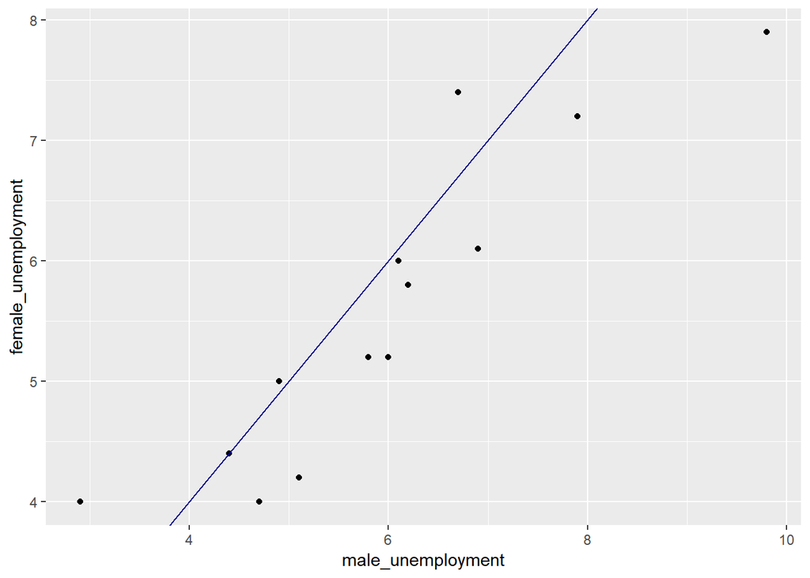

```r
library(ggplot2)

ggplot(unemployment, aes(x = male_unemployment, y = female_unemployment)) +
  geom_point() +
  geom_abline(color = "darkblue")
```

### 1.2) Regressão multivariada

Para os exemplos de regressão multivariada será utilizado o dataset bloodpressure, no qual irei modelar a pressão em função do peso e idade. Fonte dos dados: http://college.cengage.com/mathematics/brase/understandable_statistics/7e/students/datasets/mlr/frames/frame.html.

```r
# importando os dados
bloodpressure <- read.delim(file = "bloodpressure.txt", sep = "")

# verificando os quantis dos dados
summary(bloodpressure[,2:4])
```

```
##  blood_pressure       age            weight
##  Min.   :128.0   Min.   :46.00   Min.   :167
##  1st Qu.:140.0   1st Qu.:56.50   1st Qu.:186
##  Median :153.0   Median :64.00   Median :194
##  Mean   :150.1   Mean   :62.45   Mean   :195
##  3rd Qu.:160.5   3rd Qu.:69.50   3rd Qu.:209
##  Max.   :168.0   Max.   :74.00   Max.   :220
```

```r
# criando a fórmula
fmla <- blood_pressure ~ age + weight

# fitando o modelo: bloodpressure_model
bloodpressure_model <- lm(fmla, data = bloodpressure)

# examinando o modelo
summary(bloodpressure_model)
```

```
##
## Call:
## lm(formula = fmla, data = bloodpressure)
##
## Residuals:
##     Min      1Q  Median      3Q     Max
## -3.4640 -1.1949 -0.4078  1.8511  2.6981
##
## Coefficients:
##             Estimate Std. Error t value Pr(>|t|)
## (Intercept)  30.9941    11.9438   2.595  0.03186 *
## age           0.8614     0.2482   3.470  0.00844 **
## weight        0.3349     0.1307   2.563  0.03351 *
## ---
## Signif. codes:  0 '***' 0.001 '**' 0.01 '*' 0.05 '.' 0.1 ' ' 1
##
## Residual standard error: 2.318 on 8 degrees of freedom
## Multiple R-squared:  0.9768, Adjusted R-squared:  0.9711
## F-statistic: 168.8 on 2 and 8 DF,  p-value: 2.874e-07
```

Uma das vantagens da regressão linear é que você pode interpretar os efeitos de cada variável independente. Nesse caso, os coeficientes para idade e peso são positivos, o que indica que a pressão sanguínea tende a aumentar à medida que a idade e o peso aumentam.

Fazendo previsões com o modelo de regressão multivariada:

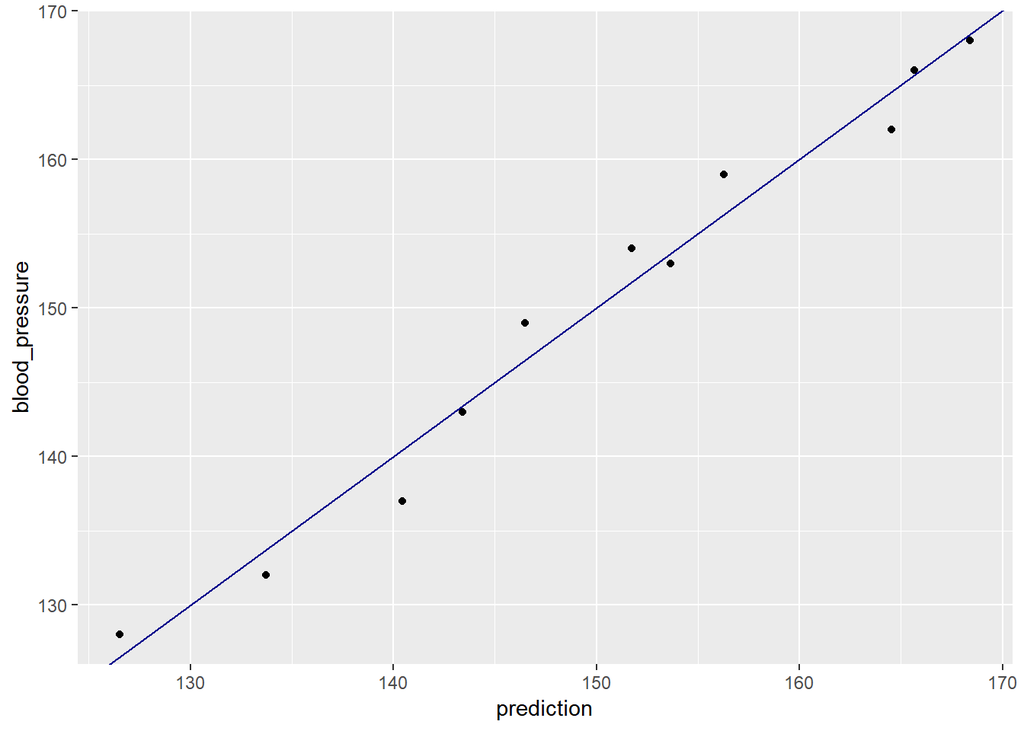

```r
# prevendo pressão usando o modelo bloodpressure_model
bloodpressure$prediction <- predict(bloodpressure_model)

# visualizando os resultados
ggplot(bloodpressure, aes(x = prediction, y = blood_pressure)) +
  geom_point() +
  geom_abline(color = "darkblue")
```

Os resultados do modelo ficaram bem ajustados aos dados observados da variável dependente, indicando que o modelo se ajusta bem aos dados de treinamento. A partir de uma perspectiva de previsão, a regressão linear multivariada se comporta da mesma forma que a simples (que possui apenas uma variável).

## 2) Avaliando e treinando modelos de regressão

Agora que foram abordados os modelos mais básicos de regressão linear, veremos como avaliar o desempenho dos modelos graficamente, assim como abordarei duas métricas básicas para modelos de regressão. Também aprenderemos como treinar um modelo de modo que ele funcione bem para dados não vistos no dataset, e não apenas em dados de treinamento.

### 2.1) Avaliando o modelo de regressão

Aqui visualizaremos o quanto o modelo e suas previsões podem errar, chamamos isso de residuais do modelo. Na sequência faremos o cálculo do quanto um modelo pode errar em média.

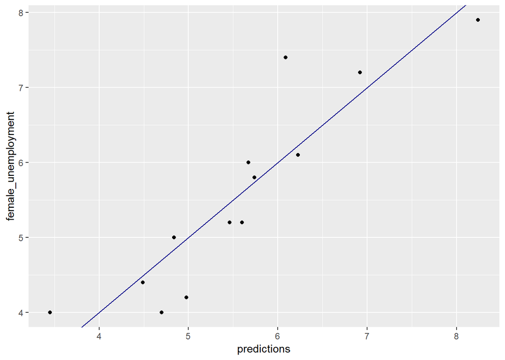

```r
# previsão do modelo
unemployment$predictions <- predict(unemployment_model)

# previsão X variável dependente
ggplot(unemployment, aes(x = predictions, y = female_unemployment)) +
  geom_point() +
  geom_abline(color = "darkblue")
```

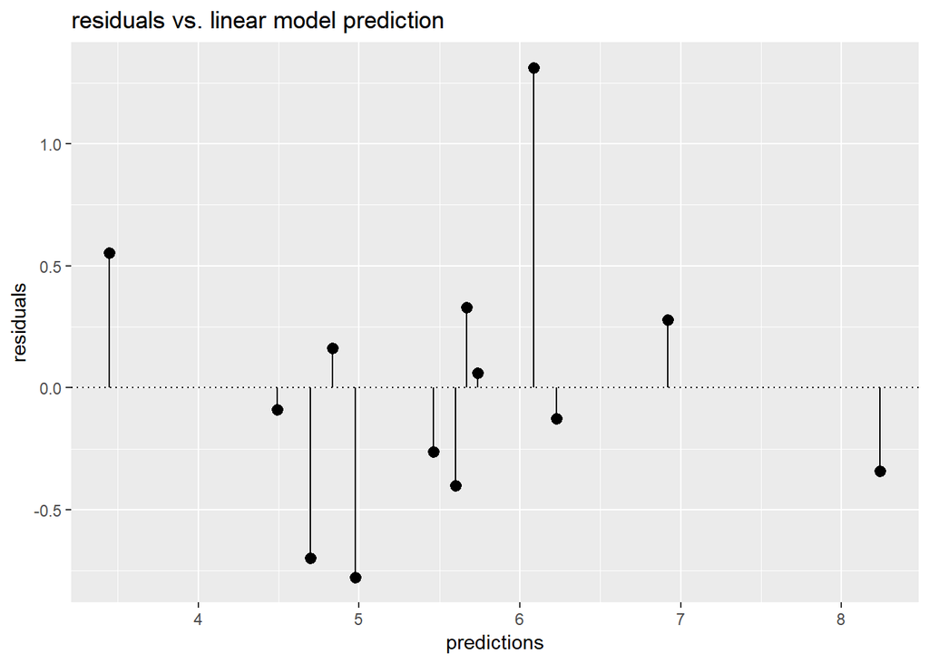

```r
# calculando o residual
unemployment$residuals <- unemployment$female_unemployment - unemployment$predictions

# visualizando os residuais do modelo
ggplot(unemployment, aes(x = predictions, y = residuals)) +
  geom_pointrange(aes(ymin = 0, ymax = residuals)) +
  geom_hline(yintercept = 0, linetype = 3) +
  ggtitle("residuals vs. linear model prediction")
```

### 2.1.1) Raíz da média dos residuais ao quadrado

O root-mean-square error (RMSE), em português é raíz da média dos residuais ao quadrado, que mostra o quanto a previsão do modelo está errando, essa é uma das métricas de acurácia de um modelo de regressão linear.

```r
# criando um objeto para os residuais do modelo
res <- unemployment$residuals

# calculando a RMSE
rmse <- sqrt(mean(res^2))
rmse
```

```
## [1] 0.5337612
```

```r
# calculando o desvio padrão da variável dependente
sd_unemployment <- sd(unemployment$female_unemployment)
sd_unemployment
```

```
## [1] 1.314271
```

Um RMSE menor que o desvio padrão da variável dependente, sugere um modelo que prevê bem.

### 2.1.2) Cálculo do R²

Agora que vimos o RMSE das previsões do modelo, examinarei como o modelo se ajusta aos dados: ou seja, quanto de variação ele explica, e isso é feito usando R².

o R² é dado por:

$$R² = 1- \frac{\sum_{i=1}^n (y_i-\hat{y}_i)^2}{\sum_{i=1}^n (y_i-\overline{y})^2}$$

O R² sempre vai de 0 até 1, indicando em percentagem o quanto o modelo consegue explicar os valores observados da variável dependente.

```r
# cálculo da soma dos residuais ao quadrado (numerador)
rss <- sum(unemployment$residuals^2)
rss
```

```
## [1] 3.703713
```

```r
# cálculo da soma dos erros ao quadrado (denominador)
fe_mean <- mean(unemployment$female_unemployment) # média da variável dependente
tss <- sum((unemployment$female_unemployment - fe_mean)^2)
tss
```

```
## [1] 20.72769
```

```r
# cálculo do R²
rsq <- 1 - (rss/tss)
rsq
```

```
## [1] 0.8213157
```

Legal! o R² é de 0,8213157, isto significa que 82,13% da variável dependente consegue ser explicada pelo modelo!

### 2.2) Gerando datasets de treino e teste

Para os seguintes exemplos usarei o dataset mpg do pacote ggplot2, esse dataset contém características de vários modelos de carros com diferentes anos de fabricação. O objetivo aqui será prever o consumo de combustível na cidade e na estrada pelos carros.

Irei explodir o dataset mpg em um dataset de treino contendo 75% das observações do dataset, e um de treino contendo 25% das observações.

```r
# explorando o dataset
summary(mpg)
```

```
##  manufacturer          model               displ            year
##  Length:234         Length:234         Min.   :1.600   Min.   :1999
##  Class :character   Class :character   1st Qu.:2.400   1st Qu.:1999
##  Mode  :character   Mode  :character   Median :3.300   Median :2004
##                                        Mean   :3.472   Mean   :2004
##                                        3rd Qu.:4.600   3rd Qu.:2008
##                                        Max.   :7.000   Max.   :2008
##       cyl           trans               drv                 cty
##  Min.   :4.000   Length:234         Length:234         Min.   : 9.00
##  1st Qu.:4.000   Class :character   Class :character   1st Qu.:14.00
##  Median :6.000   Mode  :character   Mode  :character   Median :17.00
##  Mean   :5.889                                         Mean   :16.86
##  3rd Qu.:8.000                                         3rd Qu.:19.00
##  Max.   :8.000                                         Max.   :35.00
##       hwy             fl               class
##  Min.   :12.00   Length:234         Length:234
##  1st Qu.:18.00   Class :character   Class :character
##  Median :24.00   Mode  :character   Mode  :character
##  Mean   :23.44
##  3rd Qu.:27.00
##  Max.   :44.00
```

```r
# verificando as dimensões do dataset
dim(mpg)
```

```
## [1] 234  11
```

```r
# criando a amostra aleatória do data set
set.seed(1)
sample_rows <- sample(nrow(mpg), nrow(mpg) * 0.75)

# criando o data set de treino
mpg_train <- mpg[sample_rows, ]

# criando o data set de teste
mpg_test <- mpg[-sample_rows, ]

# usando o nrow() para examinar o número de observações (linhas) do dataset mpg_train
nrow(mpg_train)
```

```
## [1] 175
```

```r
# usando o nrow() para examinar o número de observações (linhas) do dataset mpg_test
nrow(mpg_test)
```

```
## [1] 59
```

Treinando o modelo:

```r
# criando a fórmula expressando o consumo de combustível urbano (cty) em função do consumo na estrada (hwy)
fmla <- cty ~ hwy

# modelo utilizando o dataset de treino
mpg_model <- lm(fmla, data = mpg_train)

# verificando o modelo
summary(mpg_model)
```

```
##
## Call:
## lm(formula = fmla, data = mpg_train)
##
## Residuals:
##     Min      1Q  Median      3Q     Max
## -2.8339 -0.7900 -0.0698  0.5774  4.7549
##
## Coefficients:
##             Estimate Std. Error t value Pr(>|t|)
## (Intercept)  0.92360    0.40024   2.308   0.0222 *
## hwy          0.67641    0.01656  40.843   <2e-16 ***
## ---
## Signif. codes:  0 '***' 0.001 '**' 0.01 '*' 0.05 '.' 0.1 ' ' 1
##
## Residual standard error: 1.254 on 173 degrees of freedom
## Multiple R-squared:  0.906,  Adjusted R-squared:  0.9055
## F-statistic:  1668 on 1 and 173 DF,  p-value: < 2.2e-16
```

A seguir utilizarei o modelo mpg_model para previsões sobre o dataset de treino:

```r
library(Metrics) # para função rmse
library(tsensembler) # para função r_squared

# prevendo o consumo urbano de combustível pelo consumo na estrada usando o dataset de treino
mpg_train$pred <- predict(mpg_model)

# prevendo o consumo urbano de combustível pelo consumo na estrada usando o dataset de teste
mpg_test$pred <- predict(mpg_model, newdata = mpg_test)

# verificando o erro (RMSE) dos datasets de treino e de teste
rmse_train <- rmse(mpg_train$pred, mpg_train$cty)
rmse_train
```

```
## [1] 1.246845
```

```r
rmse_test <- rmse(mpg_test$pred, mpg_test$cty)
rmse_test
```

```
## [1] 1.260399
```

```r
# verificando o R² dos datasets de treino e de teste
rsq_train <- r_squared(mpg_train$pred, mpg_train$cty)
rsq_train
```

```
## [1] 0.8962928
```

```r
rsq_test <- r_squared(mpg_test$pred, mpg_test$cty)
rsq_test
```

```
## [1] 0.9189295
```

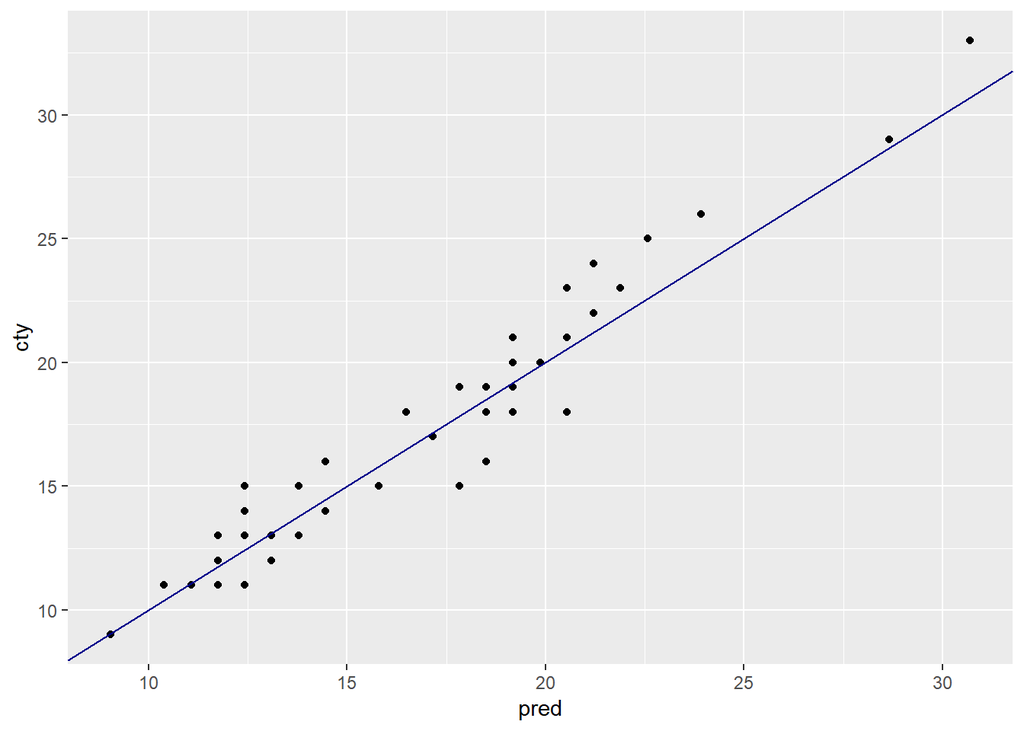

```r
# visualizando as previsões (no eixo x) pela variável dependente cty (no eixo y) do dataset de teste
ggplot(mpg_test, aes(x = pred, y = cty)) +
  geom_point() +
  geom_abline(color = "darkblue")
```

Impressionante! O R² do dataset de teste está melhor que o dataset de treino ;)

### 2.3) Método de validação cruzada

A validação cruzada é uma técnica para avaliar a capacidade de generalização de um modelo a partir de um conjunto de dados. Esta técnica é amplamente empregada em problemas onde o objetivo da modelagem é a previsão. Busca-se então estimar o quão preciso é este modelo na prática, ou seja, o seu desempenho para um novo conjunto de dados. Fonte: https://pt.wikipedia.org/wiki/Validação_cruzada

Validação cruzada na prática:

```r
library(vtreat) # para a função kWayCrossValidation

# número de linhas do dataset
nRows <- nrow(mpg)

# criando uma lista com três reamostragens dos datasets de treino e de teste
splitPlan <- kWayCrossValidation(nRows, 3, NULL, NULL)

# verificando as reamostragens
str(splitPlan)
```

```
## List of 3
##  $ :List of 2
##   ..$ train: int [1:156] 3 4 6 7 8 9 10 11 12 16 ...
##   ..$ app  : int [1:78] 172 68 114 170 121 22 127 229 46 38 ...
##  $ :List of 2
##   ..$ train: int [1:156] 1 2 5 6 7 9 10 12 13 14 ...
##   ..$ app  : int [1:78] 210 140 44 198 161 156 201 24 165 107 ...
##  $ :List of 2
##   ..$ train: int [1:156] 1 2 3 4 5 8 11 13 14 15 ...
##   ..$ app  : int [1:78] 151 208 202 43 209 85 61 179 56 221 ...
##  - attr(*, "splitmethod")= chr "kwaycross"
```

Agora usarei a lista de reamostragens criada.

```r
# rodando o 3-fold cross validation do slitPlan

k <- 3 # número de reamostragens

mpg$pred.cv <- 0

for(i in 1:k) {
  split <- splitPlan[[i]]
  model <- lm(cty ~ hwy, data = mpg[split$train, ])
  mpg$pred.cv[split$app] <- predict(model, newdata = mpg[split$app, ])
}
```

Vou comparar a acurácia do modelo sem validação cruzada com a acurácia para os dados reamostrados pela validação cruzada:

```r
# modelo de todos os dados do dataset eo RMSE
mpg$pred <- predict(lm(cty ~ hwy, data = mpg))
rmse(mpg$pred, mpg$cty)
```

```
## [1] 1.247045
```

```r
# RMSE das previsões da validação cruzada
rmse(mpg$pred.cv, mpg$cty)
```

```
## [1] 1.260693
```

Legal! Podemos ver que o erro para dados não vistos através da validação cruzada é maior!

**Outras considerações:** Antes de seguir com técnicas de regressão mais avançadas, examinaremos outros problemas de modelagem:

- modelagem com variáveis categóricas;
- interações entre variáveis
- transformação de variáveis independentes e dependentes antes da modelagem.

Embora as técnicas de regressão mais sofisticadas gerenciem alguns desses problemas automaticamente, é importante estar ciente deles, a fim de entender quais métodos lidam melhor com esses problemas.

## 3) Variáveis categóricas no modelo

Nessa parte, chamarei a função model.matrix() para examinar como o R representa dados com entradas categóricas e numéricas para modelagem. Usaremos o dataset flowers do pacote Sleuth3 que possue as seguintes variáveis:

- *Flowers*: média de flores da planta **limnanthes floccosa**;
- *Intensity*: a intensidade de de luz que a planta recebeu;
- *Time*: possui as classes Late e Early, que mostra quando que no ciclo de vida da planta ela recebeu luz com mais intensidade;

O objetivo aqui é prever a florada (Flowers) da planta em função do tempo (Time) e da intensidade de luz (Intensity).

```r
library(Sleuth3)

# explorando o dataset
flowers <- case0901
flowers$Time <- ifelse(flowers$Time == 1, "Late", "Early")
str(flowers)
```

```
## 'data.frame':    24 obs. of  3 variables:
##  $ Flowers  : num  62.3 77.4 55.3 54.2 49.6 61.9 39.4 45.7 31.3 44.9 ...
##  $ Time     : chr  "Late" "Late" "Late" "Late" ...
##  $ Intensity: int  150 150 300 300 450 450 600 600 750 750 ...
```

```r
# usando a função unique() é possível ver quais são os valores possíveis da variável Time
unique(flowers$Time)
```

```
## [1] "Late"  "Early"
```

```r
# fórmula que expressa Flowers em função de Intensity e Time
fmla <- as.formula("Flowers ~ Intensity + Time")

# usando o fmla e a função model.matrix para ver como os dados são representados para modelagem
mmat <- model.matrix(fmla, flowers)

# verificando as primeiras 20 linhas do dataset flowers
head(flowers, n = 20)
```

```
##    Flowers  Time Intensity
## 1     62.3  Late       150
## 2     77.4  Late       150
## 3     55.3  Late       300
## 4     54.2  Late       300
## 5     49.6  Late       450
## 6     61.9  Late       450
## 7     39.4  Late       600
## 8     45.7  Late       600
## 9     31.3  Late       750
## 10    44.9  Late       750
## 11    36.8  Late       900
## 12    41.9  Late       900
## 13    77.8 Early       150
## 14    75.6 Early       150
## 15    69.1 Early       300
## 16    78.0 Early       300
## 17    57.0 Early       450
## 18    71.1 Early       450
## 19    62.9 Early       600
## 20    52.2 Early       600
```

```r
# verificando as primeiras 20 linhas do dataset mmat
head(mmat, n = 20)
```

```
##    (Intercept) Intensity TimeLate
## 1            1       150        1
## 2            1       150        1
## 3            1       300        1
## 4            1       300        1
## 5            1       450        1
## 6            1       450        1
## 7            1       600        1
## 8            1       600        1
## 9            1       750        1
## 10           1       750        1
## 11           1       900        1
## 12           1       900        1
## 13           1       150        0
## 14           1       150        0
## 15           1       300        0
## 16           1       300        0
## 17           1       450        0
## 18           1       450        0
## 19           1       600        0
## 20           1       600        0
```

Agora é possível ver como a maioria das funções de modelagem no R representam variáveis categóricas internamente.

```r
# modelo
flower_model <- lm(fmla, data = flowers)

# examinando o modelo
summary(flower_model)
```

```
##
## Call:
## lm(formula = fmla, data = flowers)
##
## Residuals:
##    Min     1Q Median     3Q    Max
## -9.652 -4.139 -1.558  5.632 12.165
##
## Coefficients:
##               Estimate Std. Error t value Pr(>|t|)
## (Intercept)  83.464167   3.273772  25.495  < 2e-16 ***
## Intensity    -0.040471   0.005132  -7.886 1.04e-07 ***
## TimeLate    -12.158333   2.629557  -4.624 0.000146 ***
## ---
## Signif. codes:  0 '***' 0.001 '**' 0.01 '*' 0.05 '.' 0.1 ' ' 1
##
## Residual standard error: 6.441 on 21 degrees of freedom
## Multiple R-squared:  0.7992, Adjusted R-squared:   0.78
## F-statistic: 41.78 on 2 and 21 DF,  p-value: 4.786e-08
```

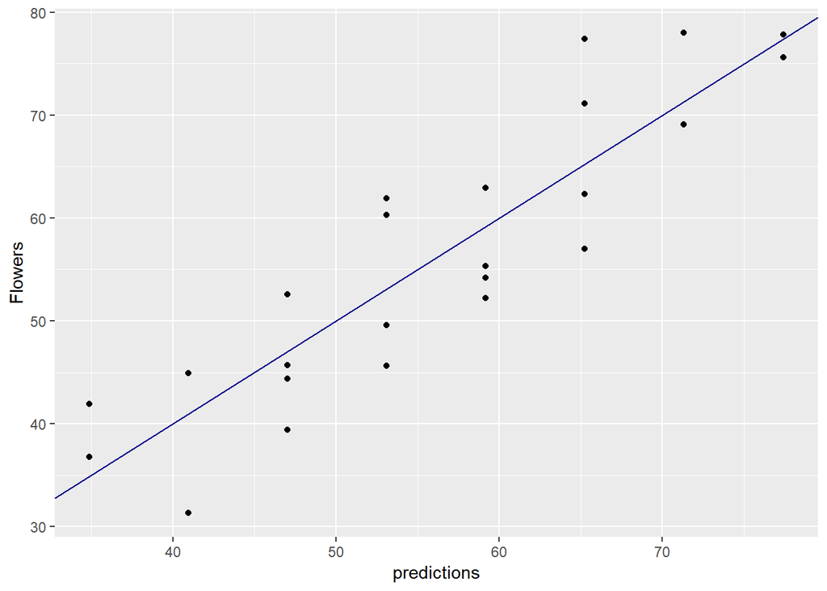

```r
# prevendo o número de flores
flowers$predictions <- predict(flower_model)

# visualizando as previsões
ggplot(flowers, aes(x = predictions, y = Flowers)) +
  geom_point() +
  geom_abline(color = "darkblue")
```

Legal! Criei um modelo com variável categórica ;)

## 4) Modelando interações

Nessa parte verificarei interações entre as variáveis para modelar o efeito do gênero e da atividade gástrica no metabolismo do álcool.

O dataset alcohol possui as seguintes variáveis:

- *Metabol*: taxa de matabolismo de álcool;
- *Gastric*: a taxa de atividade desidrogenase gástrica do álcool;
- *Sex*: sexo masculino ou feminino;

```r
# importando o dataset alcohol
alcohol <- read.csv("alcohol.csv", sep = ";")

# fórmula do modelo sem interação
fmla_add <- Metabol ~ Gastric + Sex

# fórmula com interação entre variáveis
fmla_interaction <- Metabol ~  Gastric + Gastric:Sex

# fitando o modelo sem interação
model_add <- lm(fmla_add, data = alcohol)

# fitando o modelo com interação
model_interaction <- lm(fmla_interaction, data = alcohol)

# verificando os dois modelos
summary(model_add)
```

```
##
## Call:
## lm(formula = fmla_add, data = alcohol)
##
## Residuals:
##     Min      1Q  Median      3Q     Max
## -2.2779 -0.6328 -0.0966  0.5783  4.5703
##
## Coefficients:
##             Estimate Std. Error t value Pr(>|t|)
## (Intercept)  -1.9466     0.5198  -3.745 0.000796 ***
## Gastric       1.9656     0.2674   7.352 4.24e-08 ***
## SexMale       1.6174     0.5114   3.163 0.003649 **
## ---
## Signif. codes:  0 '***' 0.001 '**' 0.01 '*' 0.05 '.' 0.1 ' ' 1
##
## Residual standard error: 1.331 on 29 degrees of freedom
## Multiple R-squared:  0.7654, Adjusted R-squared:  0.7492
## F-statistic: 47.31 on 2 and 29 DF,  p-value: 7.41e-10
```

```r
summary(model_interaction)
```

```
##
## Call:
## lm(formula = fmla_interaction, data = alcohol)
##
## Residuals:
##     Min      1Q  Median      3Q     Max
## -2.4656 -0.5091  0.0143  0.5660  4.0668
##
## Coefficients:
##                 Estimate Std. Error t value Pr(>|t|)
## (Intercept)      -0.7504     0.5310  -1.413 0.168236
## Gastric           1.1489     0.3450   3.331 0.002372 **
## Gastric:SexMale   1.0422     0.2412   4.321 0.000166 ***
## ---
## Signif. codes:  0 '***' 0.001 '**' 0.01 '*' 0.05 '.' 0.1 ' ' 1
##
## Residual standard error: 1.204 on 29 degrees of freedom
## Multiple R-squared:  0.8081, Adjusted R-squared:  0.7948
## F-statistic: 61.05 on 2 and 29 DF,  p-value: 4.033e-11
```

A interação entre as variáveis parece dar um melhor ajuste aos dados.

Como esse dataset é pequeno, usarei a validação cruzada para simular previsões com dados não vistos.

```r
library(tidyverse) # para as funções gather, mutate etc

# criando o arquivo com 3 reamostragens
set.seed(34245)  # para possibilitar a reprodução do resultado desse modelo
splitPlan <- kWayCrossValidation(nrow(alcohol), 3, NULL, NULL)

# modelo das reamostragens sem interação
alcohol$pred_add <- 0 # vetor de previsão

for(i in 1:3) {
  split <- splitPlan[[i]]
  model_add <- lm(fmla_add, data = alcohol[split$train, ])
  alcohol$pred_add[split$app] <- predict(model_add, newdata = alcohol[split$app, ])
}

# modelo das reamostragens com interação
alcohol$pred_interaction <- 0 # vetor de previsão

for(i in 1:3) {
  split <- splitPlan[[i]]
  model_interaction <- lm(fmla_interaction, data = alcohol[split$train, ])
  alcohol$pred_interaction[split$app] <- predict(model_interaction, newdata = alcohol[split$app, ])
}

# RMSE
alcohol %>%
  gather(key = modeltype, value = pred, pred_add, pred_interaction) %>%
  mutate(residuals = Metabol - pred) %>%
  group_by(modeltype) %>%
  summarize(rmse = sqrt(mean(residuals^2)))
```

```
## # A tibble: 2 x 2
##   modeltype         rmse
##   <chr>            <dbl>
## 1 pred_add          1.64
## 2 pred_interaction  1.38
```

A validação cruzada mostrou aqui que um modelo com interação dá melhores previsões, o R² está melhor e o erro do modelo (RMSE) no caso diminuiu.

## 5) Transformação da variável dependente

```r
# carregando o arquivo
library(readxl)
fdata <- read_excel(path = "fdata.xlsx", sheet = 1)

# verificando os quantis
summary(fdata)
```

```
##        y                 pred             label
##  Min.   :  -5.894   Min.   :   1.072   Length:100
##  1st Qu.:   5.407   1st Qu.:   6.373   Class :character
##  Median :  57.374   Median :  55.693   Mode  :character
##  Mean   : 306.204   Mean   : 305.905
##  3rd Qu.: 550.903   3rd Qu.: 547.886
##  Max.   :1101.619   Max.   :1098.896
```

```r
# examinando os dados: gerando resumos para as classes de compras grandes e pequenas
fdata %>%
  group_by(label) %>% # agrupando por compras pequenas e grandes
  summarize(min  = min(y), # valor mínimo do y
            mean = mean(y), # média do y
            max  = max(y)) # valor máximo do y
```

```
## # A tibble: 2 x 4
##   label              min   mean    max
##   <chr>            <dbl>  <dbl>  <dbl>
## 1 large purchases  96.1  606.   1102.
## 2 small purchases  -5.89   6.48   18.6
```

```r
# adicionando as colunas de residuais e de erro relativo
fdata2 <- fdata %>%
  group_by(label) %>% # agrupando pela variável "label"
  mutate(residual = pred - y, # residual
         relerr   = residual/y) # erro relativo

# comparando o RMSE com o RMSE relativo dos grupos de compras grandes e pequenas
fdata2 %>%
  group_by(label) %>%
  summarize(rmse = sqrt(mean(residual^2)), # RMSE
            rmse.rel = sqrt(mean(relerr^2))) # Raíz da média dos erros relativos ao quadrado
```

```
## # A tibble: 2 x 3
##   label            rmse rmse.rel
##   <chr>           <dbl>    <dbl>
## 1 large purchases  5.54   0.0147
## 2 small purchases  4.01   1.25
```

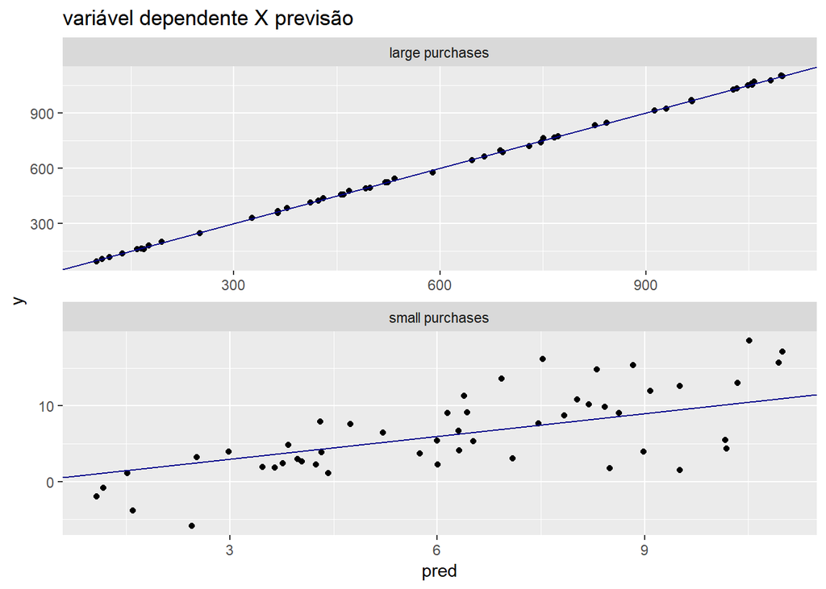

```r
# visualizando a previsão de ambos grupos de compra
ggplot(fdata2, aes(x = pred, y = y)) +
  geom_point() +
  geom_abline(color = "darkblue") +
  facet_wrap(~ label, ncol = 1, scales = "free") +
  ggtitle("variável dependente X previsão")
```

É possível observar a partir deste exemplo como um modelo com RMSE maior ainda pode ser melhor, se os erros relativos forem mais importantes que os erros absolutos.

Agora vou modelar a variável dependente log-transformada, usarei o dataset income_train e income_test.

```r
# carregando os datasets de treino e de teste
income_train <- read_excel(path = "income_train.xlsx" , sheet = 1)
income_test <- read_excel(path = "income_test.xlsx" ,sheet = 1)

# examinando a variável Income2005 na dataset de treino
summary(income_train$Income2005)
```

```
##    Min. 1st Qu.  Median    Mean 3rd Qu.    Max.
##      63   23000   39000   49894   61500  703637
```

```r
# fórmula para o log da variável Income2005
fmla.log <- log(Income2005) ~ Arith + Word + Parag + Math + AFQT

# modelo
model.log <- lm(fmla.log, data = income_train)

# fazendo previsões com o dataset de teste
income_test$logpred <- predict(model.log, newdata = income_test)
summary(income_test$logpred)
```

```
##    Min. 1st Qu.  Median    Mean 3rd Qu.    Max.
##   9.763  10.074  10.317  10.317  10.558  10.833
```

```r
# convertendo as previsões para unidades monetárias
income_test$pred.income <- exp(income_test$logpred)
summary(income_test$pred.income)
```

```
##    Min. 1st Qu.  Median    Mean 3rd Qu.    Max.
##   17379   23721   30238   31488   38488   50641
```

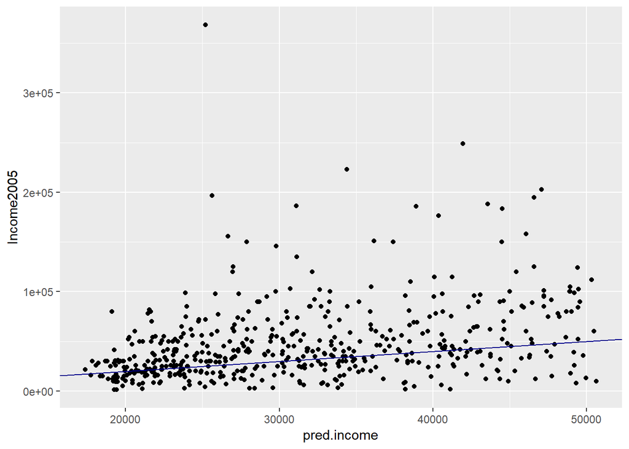

```r
# visualizando as previsões X variável dependente
ggplot(income_test, aes(x = pred.income, y = Income2005)) +
  geom_point() +
  geom_abline(color = "darkblue")
```

Lembrando que quando transformarmos a variável dependente antes da modelagem, é necessário inverter a transformação das previsões resultantes após a aplicação do modelo.

Agora vou comparar o RMSE e a raíz da média dos erros relativos ao quadrado. Vou verificar como a transformação de log da variável dependente antes da modelagem melhora o erro relativo médio (mas aumenta o RMSE) em comparação com a modelagem da variável dependente sem transformação. Você irá comparar os resultados de model.log do exercício anterior com o modelo model.abs.

```r
# fórmula do modelo fmla.abs
fmla.abs <- Income2005 ~ Arith + Word + Parag + Math + AFQT

# modelo sem transformação da variável dependente
model.abs <- lm(fmla.abs, income_train)
summary(model.abs)
```

```
##
## Call:
## lm(formula = fmla.abs, data = income_train)
##
## Residuals:
##    Min     1Q Median     3Q    Max
## -78727 -24137  -6979  11963 648573
##
## Coefficients:
##               Estimate Std. Error t value Pr(>|t|)
## (Intercept) 17522.4327  6423.9165   2.728  0.00643 **
## Arith        1552.2740   303.4467   5.115 3.42e-07 ***
## Word         -132.4587   265.0286  -0.500  0.61728
## Parag       -1155.3751   618.4642  -1.868  0.06188 .
## Math          725.4377   371.9884   1.950  0.05129 .
## AFQT            0.1778     0.1441   1.234  0.21736
## ---
## Signif. codes:  0 '***' 0.001 '**' 0.01 '*' 0.05 '.' 0.1 ' ' 1
##
## Residual standard error: 45500 on 2063 degrees of freedom
## Multiple R-squared:  0.1165, Adjusted R-squared:  0.1144
## F-statistic:  54.4 on 5 and 2063 DF,  p-value: < 2.2e-16
```

```r
# adicionando as previsões no dataset de teste
income_test <- income_test %>%
  mutate(pred.absmodel = predict(model.abs, income_test), # previsões do modelo model.abs
         pred.logmodel = exp(predict(model.log, income_test))) # previsões do modelo model.log

# juntando as previsões e calculando os residuais e o erro relativo
income_long <- income_test %>%
  gather(key = modeltype, value = pred, pred.absmodel, pred.logmodel) %>%
  mutate(residual = pred - Income2005, # residuais
         relerr   = residual / Income2005) # erro relativo

# calculando o RMSE e o erro relativo e comparando
income_long %>%
  group_by(modeltype) %>% # agrupando pela feature modeltype
  summarize(rmse = sqrt(mean(residual^2)), # RMSE
            rmse.rel = sqrt(mean(relerr^2))) # raíz da média dos erros relativos ao quadrado
```

```
## # A tibble: 2 x 3
##   modeltype       rmse rmse.rel
##   <chr>          <dbl>    <dbl>
## 1 pred.absmodel 38139.     2.53
## 2 pred.logmodel 40798.     1.97
```

É evidente que modelar o log de renda (variável dependente) pode reduzir o erro relativo do modelo, ao custo do aumento do RMSE, aqui temos um tradeoff e a escolha de fazer a transformação da variável dependente depende dos objetivos do seu projeto.

## 6) Transformação da variável independente

Vou construir um modelo para prever o preço em função do m². O dataset houseprice tem as seguintes colunas:

- *price*: preço da casa em unidades de $1.000
- *size*: área

O scatterplot dos dados mostram que os dados possuem uma relação não-linear: essa forma curva mostra que o preço é baixo para casas menores, mas sobe acentuadamente à medida que a casa aumenta. Os quadráticos e modelos ao cubo tríticos costumam ser boas formas funcionais para expressar esse tipo de relação entre as variáveis. Observe que pode não haver uma razão “física” para o preço estar relacionado ao m², o quadrática da variável indenpendente é simplesmente uma aproximação da relação observada.

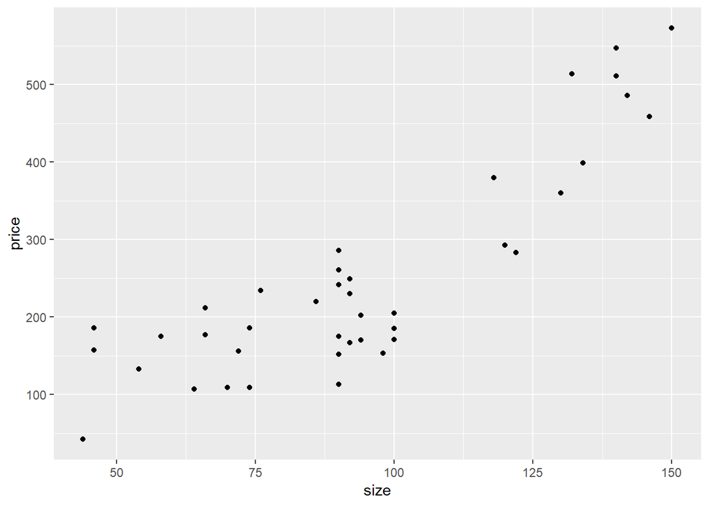

```r
# carregando o dataset
houseprice <- read_excel(path = "houseprice.xlsx", sheet = 1)

ggplot(houseprice, aes(x = size, y = price)) +
  geom_point()
```

Na sequência vou criar o modelo para prever o preço em função do m², e vou verificar o ajuste do modelo.

```r
# verificando o dataset
summary(houseprice)
```

```
##       size           price
##  Min.   : 44.0   Min.   : 42.0
##  1st Qu.: 73.5   1st Qu.:164.5
##  Median : 91.0   Median :203.5
##  Mean   : 94.3   Mean   :249.2
##  3rd Qu.:118.5   3rd Qu.:287.8
##  Max.   :150.0   Max.   :573.0
```

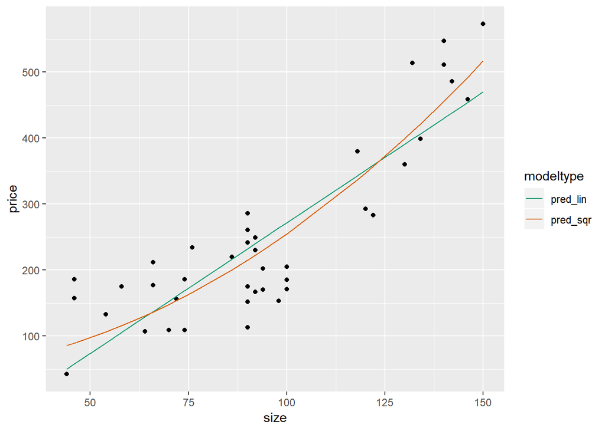

```r
# criando a fórmula de preço em função de m²
fmla_sqr <- price ~ I(size^2)

# modelo com a variável independente transformada
model_sqr <- lm(fmla_sqr, houseprice)

# modelo sem transfomação da variável independente
model_lin <- lm(price ~ size, houseprice)

# fazendo previsões e comparando
houseprice %>%
  mutate(pred_lin = predict(model_lin), # previsões do modelo linear
         pred_sqr = predict(model_sqr)) %>% # previsões do modelo quadrático
  gather(key = modeltype, value = pred, pred_lin, pred_sqr) %>% # juntando as previsões
  ggplot(aes(x = size)) +
    geom_point(aes(y = price)) +                  # actual prices
    geom_line(aes(y = pred, color = modeltype)) + # the predictions
    scale_color_brewer(palette = "Dark2")
```

A seguir irei fazer a validação cruzada do modelo linear com o modelo quadrático e verificar sua acurácia.

```r
# fórmula quadrática
fmla_sqr
```

```
## price ~ I(size^2)
```

```r
# validação cruzado com 3 reamostragens
set.seed(34245) # possibilita a replicação
splitPlan <- kWayCrossValidation(nrow(houseprice), 3, NULL, NULL)

# gerando modelos lineares das reamostragens
houseprice$pred_lin <- 0 # vetor de previsão

for(i in 1:3) {
  split <- splitPlan[[i]]
  model_lin <- lm(price ~ size, data = houseprice[split$train, ])
  houseprice$pred_lin[split$app] <- predict(model_lin, newdata = houseprice[split$app, ])
}

# gerando modelos quadráticos das reamostragens
houseprice$pred_sqr <- 0 # vetor de previsão

for(i in 1:3) {
  split <- splitPlan[[i]]
  model_sqr <- lm(fmla_sqr, data = houseprice[split$train, ])
  houseprice$pred_sqr[split$app] <- predict(model_sqr, newdata = houseprice[split$app, ])
}

# juntando as previsões para calcular os residuais
houseprice_long <- houseprice %>%
  gather(key = modeltype, value = pred, pred_lin, pred_sqr) %>%
  mutate(residuals = pred - price)

# comparando o RMSE
houseprice_long %>%
  group_by(modeltype) %>%
  summarize(rmse = sqrt(mean(residuals^2)))
```

```
## # A tibble: 2 x 2
##   modeltype  rmse
##   <chr>     <dbl>
## 1 pred_lin   74.3
## 2 pred_sqr   63.7
```

Obaa! Aquio o modelo quadrático tem a acurácia melhor que o modelo linear ;)

## 7) Modelos não-lineares

Agora começaei a examinar técnicas para modelar situações que não atendam aos pressupostos da linearidade. Isso inclui:

- prever probabilidades e frequências (valores limitados entre 0 e 1);
- previsão de contagens (valores inteiros não-negativos e taxas associadas);
- respostas que têm uma relação não-linear, mas aditiva com as entradas.

Esses tipos de algoritmos citados acima são variações do modelo linear padrão.

### 7.1) Modelo de regressão logística para prever probabilidades

Aqui vou estimar a probabilidade de um pardal sobreviver a um inverno rigoroso baseado em suas características físicas.

Usarei o dataset sparrow. A variável dependente é a *status*, e as variáveis independentes são:

- *total_length*: comprimento da ave da ponta do bico à ponta da cauda (mm);
- *weight*: peso em gramas;
- *humerus*: que é o comprimento do úmero, o “osso do braço” que liga a asa ao corpo (polegadas);

Para fazer o modelo de regressão logística usarei a função glm(), é necessário especificar o argumento *family = binomial*.

Para medir a acurácia usarei algo análogo ao R², que é o pseudo-R², que é dado por:

$$pseudoR² = 1- \frac{deviance}{null.deviance}$$

Podemos ver o deviance como algo análogo a variância, o deviance (erro) é a medida de variação em uma variável categórica.

O pseudo-R² é análogo ao R² da regressão linear padrão, o R² é uma medida da variância explicada pelo modelo de regressão linear, o pseudo-R² é a medida do erro explicado pelo modelo.

```r
library(broom) # para a função glance()

# carregando o dataset
sparrow <- read.csv(file = "sparrow.txt" , sep = "")

# verificando os quantis do dataset
summary(sparrow)
```

```
##       status         age      total_length      wingspan
##  Perished:36   adult   :59   Min.   :153.0   Min.   :236.0
##  Survived:51   juvenile:28   1st Qu.:158.0   1st Qu.:245.0
##                              Median :160.0   Median :247.0
##                              Mean   :160.4   Mean   :247.5
##                              3rd Qu.:162.5   3rd Qu.:251.0
##                              Max.   :167.0   Max.   :256.0
##      weight       beak_head        humerus           femur
##  Min.   :23.2   Min.   :29.80   Min.   :0.6600   Min.   :0.6500
##  1st Qu.:24.7   1st Qu.:31.40   1st Qu.:0.7250   1st Qu.:0.7000
##  Median :25.8   Median :31.70   Median :0.7400   Median :0.7100
##  Mean   :25.8   Mean   :31.64   Mean   :0.7353   Mean   :0.7134
##  3rd Qu.:26.7   3rd Qu.:32.10   3rd Qu.:0.7500   3rd Qu.:0.7300
##  Max.   :31.0   Max.   :33.00   Max.   :0.7800   Max.   :0.7600
```

```r
# criando a coluna survived
sparrow$survived <- sparrow$status == "Survived"

# fórmula
fmla <- survived ~ total_length + weight + humerus

# modelo de regressão logísitca
sparrow_model <- glm(fmla, data = sparrow, family = binomial)

# verificando o modelo com a função summary()
summary(sparrow_model)
```

```
##
## Call:
## glm(formula = fmla, family = binomial, data = sparrow)
##
## Deviance Residuals:
##     Min       1Q   Median       3Q      Max
## -2.1117  -0.6026   0.2871   0.6577   1.7082
##
## Coefficients:
##              Estimate Std. Error z value Pr(>|z|)
## (Intercept)   46.8813    16.9631   2.764 0.005715 **
## total_length  -0.5435     0.1409  -3.858 0.000115 ***
## weight        -0.5689     0.2771  -2.053 0.040060 *
## humerus       75.4610    19.1586   3.939 8.19e-05 ***
## ---
## Signif. codes:  0 '***' 0.001 '**' 0.01 '*' 0.05 '.' 0.1 ' ' 1
##
## (Dispersion parameter for binomial family taken to be 1)
##
##     Null deviance: 118.008  on 86  degrees of freedom
## Residual deviance:  75.094  on 83  degrees of freedom
## AIC: 83.094
##
## Number of Fisher Scoring iterations: 5
```

```r
# verificando o modelo com a função glance()
perf <- glance(sparrow_model)

# calculando o pseudo-R²
pseudoR2 <- 1 - perf$deviance/perf$null.deviance
pseudoR2
```

```
## [1] 0.3636526
```

Criei um modelo de regressão logística para prever probabilidades! Ao olhar para o pseudo-R² de um modelo de regressão logística, um valor próximo a 1 é um modelo com acurácia boa.

Agora vou prever a probabilidade de sobrevivência dos pardais usando o modelo de sobrevivência do pardal do código anterior.

Ao usar a função predict() para obter as probabilidades de um modelo derado com a função glm(), é necessário especificar o argumento *type = response*, se não a função irá devolver um resultado log-odds do evento e não a probabilidade.

```r
# criando coluna de previsão
sparrow$prob <- predict(sparrow_model, type = "response")
```

Verificando a matriz de confusão desse modelo.

```r
# definindo o treshold como a média das previsões
treshold <- mean(sparrow$prob)

# criando coluna de previsão
sparrow$pred <- ifelse(sparrow$prob <= treshold, 0, 1)

# matriz de confusão
table(sparrow$pred, sparrow$survived)
```

```
##
##     FALSE TRUE
##   0    26    9
##   1    10   42
```

```r
# acurácia
mean(sparrow$pred == 1)
```

```
## [1] 0.5977011
```

Podemos ver que a quantidade de verdadeiros positivos (ou seja, a quantidade de vezes que o modelo predizeu que o pardal sobreviveria quando de fato ele sobreviveu) é de 42.

A quantidade de verdadeiros negativos é de 26 (ou seja, a quantidade de vezes que o modelo predizeu que o pardal não sobreviveria quando de fato ele não sobreviveu) é de 26.

Agora vou verificar a acurácia do modelo pela área abaixo da curva ROC.

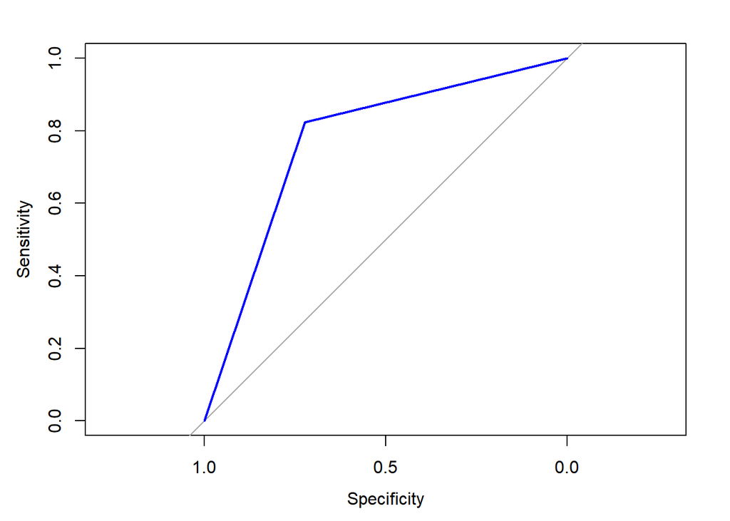

```r
# carregando o pacote pROC
library(pROC)

# criando a curva ROC
ROC <- roc(sparrow$survived, sparrow$pred)

# visualizando a curva ROC
plot(ROC, col = "blue")
```

```r
# calculando a área abaixo da curva (AUC)
auc(ROC)
```

```
## Area under the curve: 0.7729
```

O ROC é uma curva de probabilidade que mostra a sensitividade (taxa de verdadeiros positivos) e a especificidade (taxa de verdadeiros negativos) de vários valores de treshold, indo de 0 a 1.

A área abaixo da curva (AUC) ROC é uma medida de desempenho de modelos de classificação, quando a AUC é aproximadamente 0, o modelo está alternando entre as classes, isso significa que o modelo está prevendo classe negativa como uma classe positiva e vice-versa. A AUC representa o grau ou medida da separabilidade, ela informa quanto modelo é capaz de distinguir entre classes. Quanto maior a AUC, melhor o modelo prevê 0 como 0, e 1 como 1. Usando nosso exemplo, quanto maior a AUC, melhor o modelo distingue entre pardais que sobreviverão e pardais que não sobreviverão.

Aqui tem uma explicação mais detalhada sobre a AUC da curva ROC: https://towardsdatascience.com/understanding-auc-roc-curve-68b2303cc9c5

### 7.2) Regressão de Poisson e quasipoisson para prever contagens

Aqui veremos como usar técnicas de regressão para prever contagem de dados. prever contagens é um problema não linear, porque as contagens são restritas a serem não lineares e inteiros.

- **Regressão linear:** prediz valores entre [−∞,∞]
- **Contagens:** inteiros no intervalo entre [0,∞]

Uma das regras da regressão de Poisson para prever contagens é que o evento que você está contando seja uma distribição de Poisson: a contagem média por unidade de tempo é a mesma que a variância da contagem. Na prática, “o mesmo” significa que a média e a variância devem ser de uma ordem similar de magnitude.

Quando a variância é muito maior que a média, a regressão de Poisson não se aplica, e uma solução é usar a regressão de quasipoisson, que não assume que a variância deve ser igual a média.

#### 7.2.1) Modelo para prever aluguel de bicicletas

Aqui vou construir um modelo para prever o número de bicicletas alugadas em uma hora em função do clima, do tipo de dia (feriado, dia útil ou fim de semana) e da hora do dia. Irei treinar o modelo com dados do mês de julho.

O dataset contém as seguintes colunas:

- *cnt*: número de bicicletas alugadas por hora (variável dependente);
- *hr*: hora do dia (vai de 0 a 23);
- *holiday*: TRUE/FALSE;
- *workingday*: TRUE se nem é feriado e nem fim de semana, se não FALSE;
- *weathersit*: variável categórica com as seguintes classes “Clear to partly cloudy”, “Light Precipitation”, “Misty”;
- *temp*: temperatura em °C;
- *atemp*: sensação térmica em °C;
- *hum*: huminadade;
- *windspeed*: velocidade do vento;
- *instant*: index (não é uma variável);
- *mnth* e *yr*: indices de mês e ano (não é uma variável)

É necessário especificar o argumento *family = poisson* ou *family = quasipoisson* quando usar a função glm() para fitar um modelo de contagem.

```r
# verificando a estrutura de bikesJuly
bikesJuly <- read.csv("bikesJuly.csv", sep = ",")
bikesJuly$hr <- as.factor(bikesJuly$hr)
bikesJuly$weathersit <- as.character(bikesJuly$weathersit)
str(bikesJuly)
```

```
## 'data.frame':    744 obs. of  13 variables:
##  $ X         : int  1 2 3 4 5 6 7 8 9 10 ...
##  $ hr        : Factor w/ 24 levels "0","1","2","3",..: 1 2 3 4 5 6 7 8 9 10 ...
##  $ holiday   : logi  FALSE FALSE FALSE FALSE FALSE FALSE ...
##  $ workingday: logi  FALSE FALSE FALSE FALSE FALSE FALSE ...
##  $ weathersit: chr  "Clear to partly cloudy" "Clear to partly cloudy" "Clear to partly cloudy" "Clear to partly cloudy" ...
##  $ temp      : num  0.76 0.74 0.72 0.72 0.7 0.68 0.7 0.74 0.78 0.82 ...
##  $ atemp     : num  0.727 0.697 0.697 0.712 0.667 ...
##  $ hum       : num  0.66 0.7 0.74 0.84 0.79 0.79 0.79 0.7 0.62 0.56 ...
##  $ windspeed : num  0 0.1343 0.0896 0.1343 0.194 ...
##  $ cnt       : int  149 93 90 33 4 10 27 50 142 219 ...
##  $ instant   : int  13004 13005 13006 13007 13008 13009 13010 13011 13012 13013 ...
##  $ mnth      : int  7 7 7 7 7 7 7 7 7 7 ...
##  $ yr        : int  1 1 1 1 1 1 1 1 1 1 ...
```

```r
# variável dependente
outcome <- c("cnt")

# variáveis dependentes
vars <-  c("hr", "holiday", "workingday", "weathersit", "temp", "atemp", "hum", "windspeed")

# fórmula do modelo
fmla <- paste(outcome, "~", paste(vars, collapse = " + "))

# calculando a média e a variância da variável dependente
mean_bikes <- mean(bikesJuly$cnt)
mean_bikes
```

```
## [1] 273.6653
```

```r
var_bikes <- var(bikesJuly$cnt)
var_bikes
```

```
## [1] 45863.84
```

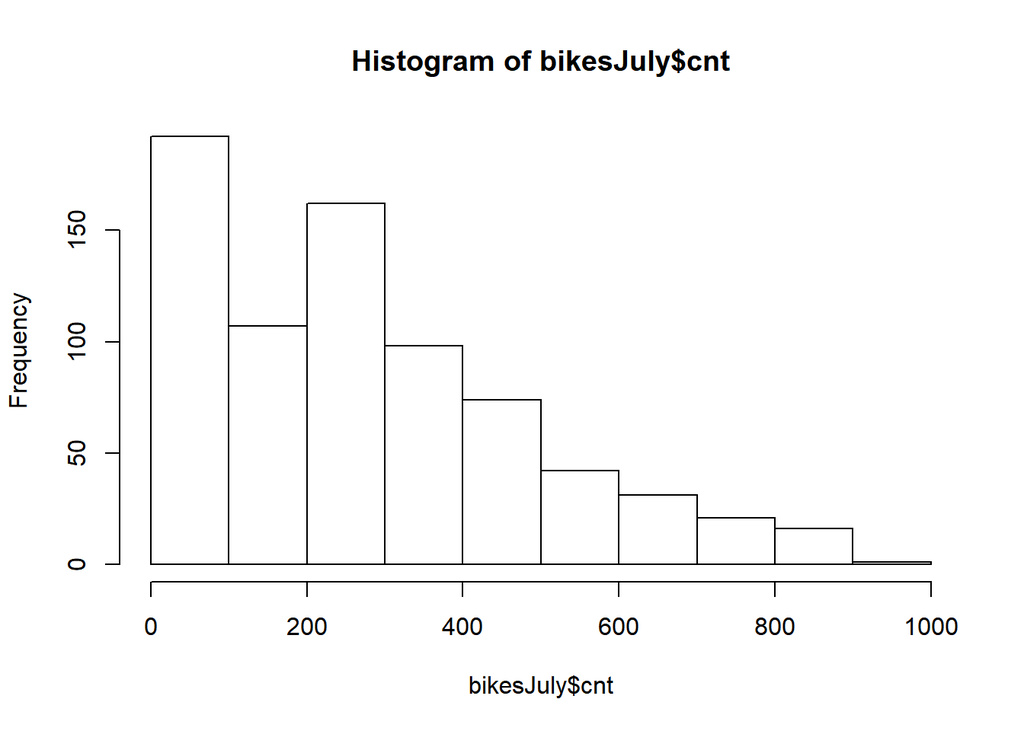

```r
# verificando a distribuição de frequência da variável dependente
hist(bikesJuly$cnt)
```

```r
# fitando o modelo
bike_model <- glm(fmla, data = bikesJuly, family = quasipoisson)

# chamando glance()
perf <- glance(bike_model)
perf
```

```
##   null.deviance df.null logLik AIC BIC deviance df.residual
## 1      133364.9     743     NA  NA  NA  28774.9         712
```

```r
# calculando o pseudo-R²
pseudoR2 <- 1 - perf$deviance/perf$null.deviance
pseudoR2
```

```
## [1] 0.7842393
```

Legal! Fiz um modelo quasipoisson para prever contagens! Como no modelo de regressão logística, esperamos um pseudo-R² próximo de 1.

Agora vou usar o modelo para previsões para o mês de Agosto.

```r
# estrutura do bikesAugust
bikesAugust <- read.csv("bikesAugust.csv", sep = ",")
bikesAugust$hr <- as.factor(bikesAugust$hr)
bikesAugust$weathersit <- as.character(bikesAugust$weathersit)
str(bikesAugust)
```

```
## 'data.frame':    744 obs. of  14 variables:
##  $ X         : int  1 2 3 4 5 6 7 8 9 10 ...
##  $ hr        : Factor w/ 24 levels "0","1","2","3",..: 1 2 3 4 5 6 7 8 9 10 ...
##  $ holiday   : logi  FALSE FALSE FALSE FALSE FALSE FALSE ...
##  $ workingday: logi  TRUE TRUE TRUE TRUE TRUE TRUE ...
##  $ weathersit: chr  "Clear to partly cloudy" "Clear to partly cloudy" "Clear to partly cloudy" "Clear to partly cloudy" ...
##  $ temp      : num  0.68 0.66 0.64 0.64 0.64 0.64 0.64 0.64 0.66 0.68 ...
##  $ atemp     : num  0.636 0.606 0.576 0.576 0.591 ...
##  $ hum       : num  0.79 0.83 0.83 0.83 0.78 0.78 0.78 0.83 0.78 0.74 ...
##  $ windspeed : num  0.1642 0.0896 0.1045 0.1045 0.1343 ...
##  $ cnt       : int  47 33 13 7 4 49 185 487 681 350 ...
##  $ instant   : int  13748 13749 13750 13751 13752 13753 13754 13755 13756 13757 ...
##  $ mnth      : int  8 8 8 8 8 8 8 8 8 8 ...
##  $ yr        : int  1 1 1 1 1 1 1 1 1 1 ...
##  $ pred      : num  94.96 51.74 37.98 17.58 9.36 ...
```

```r
# previsões para o mês de agosto
bikesAugust$pred <- predict(bike_model, newdata = bikesAugust, type = "response")

# calculando o RMSE
bikesAugust %>%
  mutate(residual = pred - cnt) %>%
  summarize(rmse  = sqrt(mean(residual^2)))
```

```
##       rmse
## 1 112.5815
```

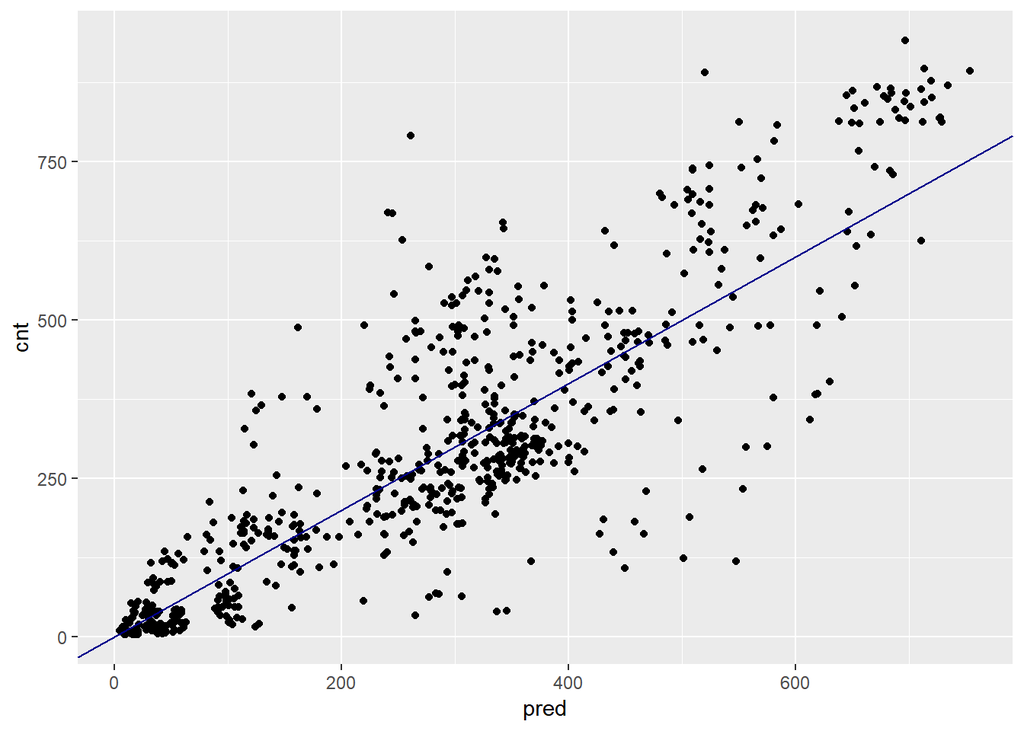

```r
# visualizando as previsões X as observações da variável dependente
ggplot(bikesAugust, aes(x = pred, y = cnt)) +
  geom_point() +
  geom_abline(color = "darkblue")
```

Visualizamos as previsões do modelo de bicicleta usando o gráfico de dispersão “resultado versus previsão”. Como os dados de aluguel de bicicletas são dados de séries temporais, é melhor saber como o modelo funciona em função do tempo. A seguir vou comparr as previsões e aluguéis reais em uma base horária, nos primeiros 14 dias de agosto.

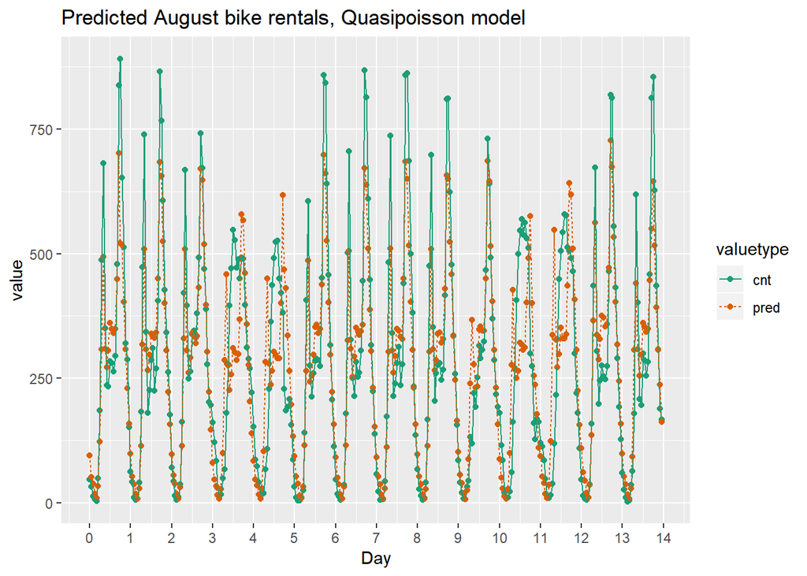

```r
# visualizando as previsões e a variável cnt por data/tempo
quasipoisson_plot <- bikesAugust %>%
  # configurando para começar em 0, convertendo unidades para dias
  mutate(instant = (instant - min(instant))/24) %>%
  # juntando cnt e pred
  gather(key = valuetype, value = value, cnt, pred) %>%
  filter(instant < 14) %>% # somente os primeiros 14 dias
  # visualizando...
  ggplot(aes(x = instant, y = value, color = valuetype, linetype = valuetype)) +
  geom_point() +
  geom_line() +
  scale_x_continuous("Day", breaks = 0:14, labels = 0:14) +
  scale_color_brewer(palette = "Dark2") +
  ggtitle("Predicted August bike rentals, Quasipoisson model")

quasipoisson_plot
```

### 7.3) Modelo aditivo generalizado

#### 7.3.1) Modelo de crescimento da soja com modelo aditivo generalizado

Aqui irei modelar o peso médio da folha em uma planta de soja em função do tempo (após o plantio). Como você verá, a planta de soja não cresce a uma taxa constante, a taxa de creciemnto dela é como se houvesse um surto de crescimento, que eventualmente diminui. Assim, o peso da folha não é bem descrito por um modelo linear.

- Para modelar uma variável de forma não linear é só usar a função s(): *y ~ s(x)*
- O modelo aditivo generalizado é dada pela função gam() do pacote mgcv: *gam(formula, family, data)*

Para a regressão padrão, usar o argumento configurado como *family = gaussian*.

O dataset soybean_train, tem duas colunas, a de peso (weight) e de tempo (Time).

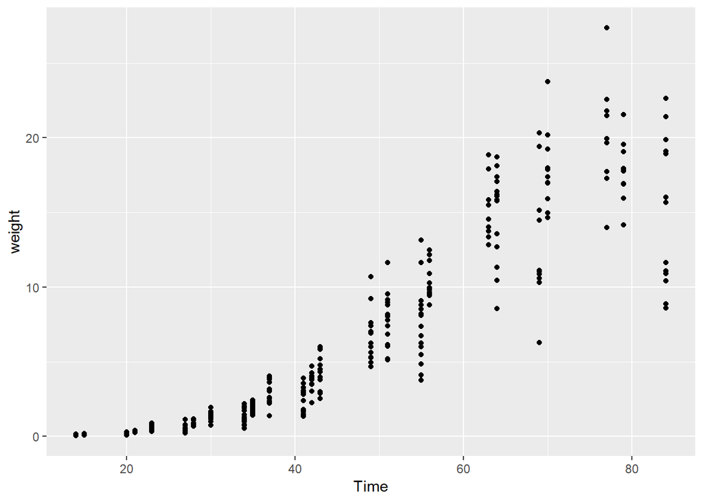

```r
# carregando o dataset soybean_train
soybean_train <- read.csv("soybean_train.csv", sep = ",")

# visualizando weight X Time (Time no eixo x)
ggplot(soybean_train, aes(x = Time, y = weight)) +
  geom_point()
```

```r
# modelo linear
model.lin <- lm(weight ~ Time, soybean_train)

# carregando o pacote mgcv
library(mgcv)

# fórmula
fmla.gam <- weight ~ s(Time)

# modelo não linear
model.gam <- gam(fmla.gam, data = soybean_train, family = gaussian)

# verificando o modelo linear
summary(model.lin)
```

```
##
## Call:
## lm(formula = weight ~ Time, data = soybean_train)
##
## Residuals:
##     Min      1Q  Median      3Q     Max
## -9.3933 -1.7100 -0.3909  1.9056 11.4381
##
## Coefficients:
##              Estimate Std. Error t value Pr(>|t|)
## (Intercept) -6.559283   0.358527  -18.30   <2e-16 ***
## Time         0.292094   0.007444   39.24   <2e-16 ***
## ---
## Signif. codes:  0 '***' 0.001 '**' 0.01 '*' 0.05 '.' 0.1 ' ' 1
##
## Residual standard error: 2.778 on 328 degrees of freedom
## Multiple R-squared:  0.8244, Adjusted R-squared:  0.8238
## F-statistic:  1540 on 1 and 328 DF,  p-value: < 2.2e-16
```

```r
# verificando o modelo não linear
summary(model.gam)
```

```
##
## Family: gaussian
## Link function: identity
##
## Formula:
## weight ~ s(Time)
##
## Parametric coefficients:
##             Estimate Std. Error t value Pr(>|t|)
## (Intercept)   6.1645     0.1143   53.93   <2e-16 ***
## ---
## Signif. codes:  0 '***' 0.001 '**' 0.01 '*' 0.05 '.' 0.1 ' ' 1
##
## Approximate significance of smooth terms:
##           edf Ref.df     F p-value
## s(Time) 8.495   8.93 338.2  <2e-16 ***
## ---
## Signif. codes:  0 '***' 0.001 '**' 0.01 '*' 0.05 '.' 0.1 ' ' 1
##
## R-sq.(adj) =  0.902   Deviance explained = 90.4%
## GCV = 4.4395  Scale est. = 4.3117    n = 330
```

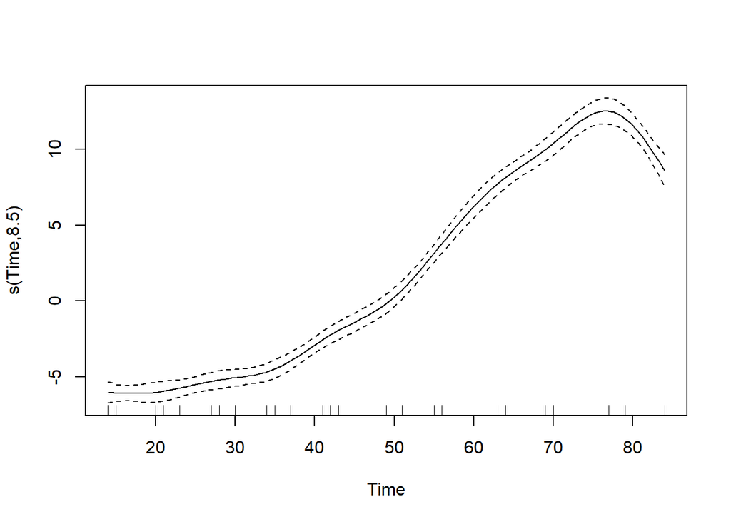

```r
# visualizando o modelo não linear
plot(model.gam)
```

Comparando os R² percebemos que o o modelo aditivo generalizado se ajusta melhor aos dados da variável dependente.

Previsões com o modelo:

```r
# carregadno o dataset de teste
soybean_test <- read.csv("soybean_test.csv", sep = ",")

# previsões com o modelo linear
soybean_test$pred.lin <- predict(model.lin, newdata = soybean_test)

# previsões com o modelo não linear
soybean_test$pred.gam <- as.numeric(predict(model.gam, newdata = soybean_test))

# juntando as previsões
soybean_long <- soybean_test %>%
  gather(key = modeltype, value = pred, pred.lin, pred.gam)

# calculando o erro do modelo (RMSE)
soybean_long %>%
  mutate(residual = weight - pred) %>% # residuais
  group_by(modeltype) %>% # agrupando pelo tipo de modelo
  summarize(rmse = sqrt(mean(residual^2))) # calculando o RMSE
```

```
## # A tibble: 2 x 2
##   modeltype  rmse
##   <chr>     <dbl>
## 1 pred.gam   2.29
## 2 pred.lin   3.19
```

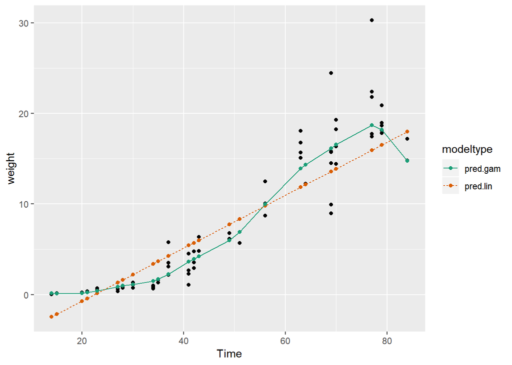

```r
# comparando as previsões
soybean_long %>%
  ggplot(aes(x = Time)) +
  geom_point(aes(y = weight)) +
  geom_point(aes(y = pred, color = modeltype)) +
  geom_line(aes(y = pred, color = modeltype, linetype = modeltype)) +
  scale_color_brewer(palette = "Dark2")
```

O modelo aditivo generalizado aprende melhor a função não-linear de crescimento das plantas de soja ;)

## 8) Modelos de árvore de decisão

Aqui abordarei algoritmos de modelagem que não assumem linearidade ou aditividade e que podem aprender tipos limitados de interação entre variáveis de entrada. Esses algoritmos são métodos baseados em árvore, que funcionam combinando conjuntos de árvores de decisão que são aprendidas com os dados de treinamento.

### 8.1) Modelo de random forest para previsão de aluguel de bicicletas

Aqui farei novamente o modelo para prever o número de alugueis de bicicleta em uma hora em função do clima, do tipo de dia (se é feriado, dia de trabalho, ou final de semana). Treinarei o modelo para o mês de Julho.

Usarei o pacote ranger para criar o modelo de random forest. Os argumentos que utilizaremos da função ranger() são:

- *formula*;
- *data*;
- *num.trees*: número de árvores da “floresta”;
- *respect.unordered.factors*: especifica como tratar as variáveis fator não ordenadas, é recomendado configurar o argumento para “order” para modelos de regressão;
- *seed*: por ser um algoritmo de aleatorização, devemos configurar o argumento seed para permitir a reprodução dos resultados

```r
# fórmula
fmla <- cnt ~ hr + holiday + workingday + weathersit + temp + atemp + hum + windspeed

# carregando o pacote ranger
library(ranger)

# modelo de random forest
bike_model_rf <- ranger(formula = fmla, data = bikesJuly, num.trees = 500, respect.unordered.factors = "order", seed = 423563)
bike_model_rf
```

```
## Ranger result
##
## Call:
##  ranger(formula = fmla, data = bikesJuly, num.trees = 500, respect.unordered.factors = "order",      seed = 423563)
##
## Type:                             Regression
## Number of trees:                  500
## Sample size:                      744
## Number of independent variables:  8
## Mtry:                             2
## Target node size:                 5
## Variable importance mode:         none
## Splitrule:                        variance
## OOB prediction error (MSE):       8230.568
## R squared (OOB):                  0.8205434
```

Criei um modelo de random forest com um bom R².

A seguir mostrarei como ele funciona nos dados de validação.

Prevendo alugueis de bicicletas com o modelo de random forest:

```r
# fazendo previsões com os dados de agosto
bikesAugust$pred <- predict(bike_model_rf, bikesAugust)$predictions

# calculando o erro das previsões (RMSE)
bikesAugust %>%
  mutate(residual = cnt - pred)  %>%
  summarize(rmse  = sqrt(mean(residual^2)))
```

```
##       rmse
## 1 97.18347
```

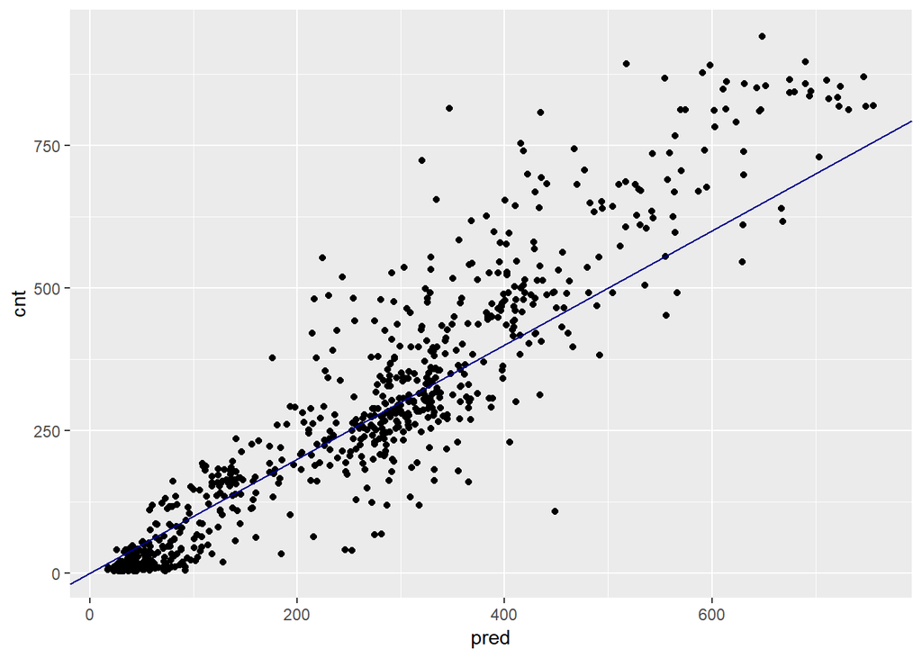

```r
# visualizando a variável dependente X previsões (previsões no eixo x)
ggplot(bikesAugust, aes(x = pred, y = cnt)) +
  geom_point() +
  geom_abline(color = "darkblue")
```

É possível notar que o modelo de random forest para aluguel de bicicletas ficou melhor do que o modelo de quasipoisson, quando comparamos o RMSE.

Agora vou visualizações das previsões de agosto do modelo de random forest em função do tempo.

Lembre-se de que o modelo de quasipoisson identificou principalmente o padrão de horas com menos alugueis no dia, mas subestimou um pouco as demandas de pico. Vamos ver como o modelo de random forest lida com isso.

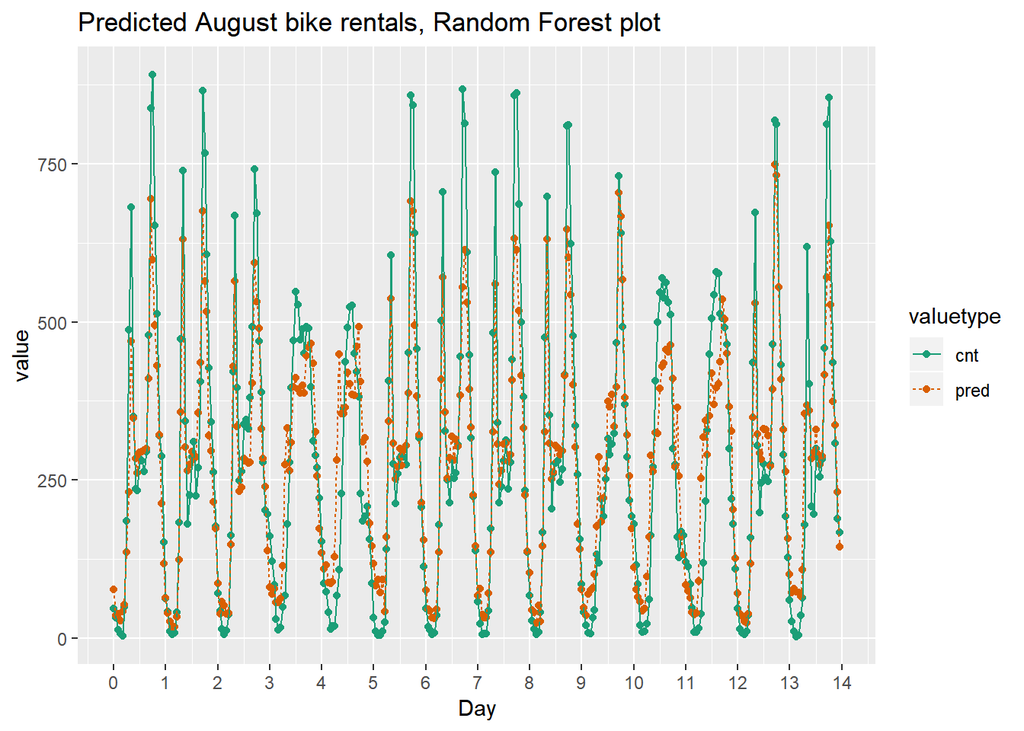

```r
first_two_weeks <- bikesAugust %>%
  # configurando para começar no dia 0, convertendo unidades em dias
  mutate(instant = (instant - min(instant)) / 24) %>%
  #juntando cnt e pred em uma coluna
  gather(key = valuetype, value = value, cnt, pred) %>%
  filter(instant < 14)

# visualizando previsões e cnt pela data/tempo
randomforest_plot <- ggplot(first_two_weeks, aes(x = instant, y = value, color = valuetype, linetype = valuetype)) +
  geom_point() +
  geom_line() +
  scale_x_continuous("Day", breaks = 0:14, labels = 0:14) +
  scale_color_brewer(palette = "Dark2") +
  ggtitle("Predicted August bike rentals, Random Forest plot")

randomforest_plot
```

O modelo de random forest capturou as variações do dia-a-dia na demanda de pico melhor do que o modelo de quasipoisson, mas ainda subestima a demanda de pico e também superestima a demanda mínima. Portanto, ainda há possibilidade de melhorias.

### 8.2) One-Hot-Encoding para uso do dataset pelo xgboost ;)

Boa explicação dessa técnica: https://hackernoon.com/what-is-one-hot-encoding-why-and-when-do-you-have-to-use-it-e3c6186d008f?gi=d5f0d8889c3a

#### 8.2.1) vtreat em um pequeno exemplo

```r
# carregando o dframe
dframe <- read.csv("dframe.csv", sep = ";")

# criando o vetor com o nome das variáveis
vars <- c("color", "size")

# carregadno os pacotes necessários
library(vtreat)
library(magrittr) # para a função use_series()

# criando o plano de tratamento
treatplan <- designTreatmentsZ(dframe, vars)
```

```
## [1] "vtreat 1.3.6 inspecting inputs Wed Mar 13 08:17:45 2019"
## [1] "designing treatments Wed Mar 13 08:17:45 2019"
## [1] " have initial level statistics Wed Mar 13 08:17:45 2019"
## [1] " scoring treatments Wed Mar 13 08:17:45 2019"
## [1] "have treatment plan Wed Mar 13 08:17:45 2019"
```

```r
# examinando o scoreFrame
scoreFrame <- treatplan %>%
  use_series(scoreFrame) %>%
  select(varName, origName, code)

# queremos somente as linhas com "clean" ou "lev"
newvars <- scoreFrame %>%
  filter(code %in% c("clean", "lev")) %>%
  use_series(varName)

# criando o dados treinados tratados
dframe.treat <- prepare(treatplan, dframe, varRestriction = newvars)
```

Quando uma classe de uma variável categórica é rara, pode ser que ela não seja exibida nos dados de treinamento. Se esse nível raro aparecer em dados futuros, o modelo pode não saber o que fazer com ele. Quando tais novos níveis aparecem, usando model.matrix ou o caret::dummyVars para fazer o one-hot-enconde, isso pode não fazer o trabalho necessário corretamente.

O vtreat é uma alternativa segura para o model.matrix para tarefa de one-hot-encoding, porque ele pode gerenciar novos níveis com segurança. vtreat também gerencia valores ausentes nos dados (tanto categóricos quanto contínuos).

Veremos como o vtreat lida com valores categóricos que não aparecem no dataset de treino.

```r
# carregando o dataset de treino testframe
testframe <- read.csv("testframe.csv", sep = ";")

# usando a função prepare() para fazer o one-hot-encode no testframe
testframe.treat <- prepare(treatplan, testframe, varRestriction = newvars)
```

#### 8.2.2) vtreat nos dados de aluguel de bicicletas

```r
# variáveis de entrada
vars <- c("hr", "holiday", "workingday", "weathersit", "temp", "atemp", "hum", "windspeed")

# criando o plano de tratamento para o bikesJuly (dataset de treino)
treatplan <- designTreatmentsZ(bikesJuly, vars, verbose = FALSE)

# pegando as variáveis "clean" e "lev" do scoreFrame
newvars <- treatplan %>%
  use_series(scoreFrame) %>%
  filter(code %in% c("clean", "lev")) %>%
  use_series(varName)

# preparando os dados de treino
bikesJuly.treat <- prepare(treatplan, bikesJuly,  varRestriction = newvars)

# preparando os dados de teste
bikesAugust.treat <- prepare(treatplan, bikesAugust, varRestriction = newvars)

# verificando a estrutura dos dados tratados
str(bikesJuly.treat)
```

```
## 'data.frame':    744 obs. of  33 variables:
##  $ holiday                                : num  0 0 0 0 0 0 0 0 0 0 ...
##  $ workingday                             : num  0 0 0 0 0 0 0 0 0 0 ...
##  $ temp                                   : num  0.76 0.74 0.72 0.72 0.7 0.68 0.7 0.74 0.78 0.82 ...
##  $ atemp                                  : num  0.727 0.697 0.697 0.712 0.667 ...
##  $ hum                                    : num  0.66 0.7 0.74 0.84 0.79 0.79 0.79 0.7 0.62 0.56 ...
##  $ windspeed                              : num  0 0.1343 0.0896 0.1343 0.194 ...
##  $ hr_lev_x_0                             : num  1 0 0 0 0 0 0 0 0 0 ...
##  $ hr_lev_x_1                             : num  0 1 0 0 0 0 0 0 0 0 ...
##  $ hr_lev_x_10                            : num  0 0 0 0 0 0 0 0 0 0 ...
##  $ hr_lev_x_11                            : num  0 0 0 0 0 0 0 0 0 0 ...
##  $ hr_lev_x_12                            : num  0 0 0 0 0 0 0 0 0 0 ...
##  $ hr_lev_x_13                            : num  0 0 0 0 0 0 0 0 0 0 ...
##  $ hr_lev_x_14                            : num  0 0 0 0 0 0 0 0 0 0 ...
##  $ hr_lev_x_15                            : num  0 0 0 0 0 0 0 0 0 0 ...
```

[output cut: 19 more lines]

```r
str(bikesAugust.treat)
```

```
## 'data.frame':    744 obs. of  33 variables:
##  $ holiday                                : num  0 0 0 0 0 0 0 0 0 0 ...
##  $ workingday                             : num  1 1 1 1 1 1 1 1 1 1 ...
##  $ temp                                   : num  0.68 0.66 0.64 0.64 0.64 0.64 0.64 0.64 0.66 0.68 ...
##  $ atemp                                  : num  0.636 0.606 0.576 0.576 0.591 ...
##  $ hum                                    : num  0.79 0.83 0.83 0.83 0.78 0.78 0.78 0.83 0.78 0.74 ...
##  $ windspeed                              : num  0.1642 0.0896 0.1045 0.1045 0.1343 ...
##  $ hr_lev_x_0                             : num  1 0 0 0 0 0 0 0 0 0 ...
##  $ hr_lev_x_1                             : num  0 1 0 0 0 0 0 0 0 0 ...
##  $ hr_lev_x_10                            : num  0 0 0 0 0 0 0 0 0 0 ...
##  $ hr_lev_x_11                            : num  0 0 0 0 0 0 0 0 0 0 ...
##  $ hr_lev_x_12                            : num  0 0 0 0 0 0 0 0 0 0 ...
##  $ hr_lev_x_13                            : num  0 0 0 0 0 0 0 0 0 0 ...
##  $ hr_lev_x_14                            : num  0 0 0 0 0 0 0 0 0 0 ...
##  $ hr_lev_x_15                            : num  0 0 0 0 0 0 0 0 0 0 ...
```

[output cut: 19 more lines]

Perfeito! Os dados agora estão em formato totalmente numérico, prontos para uso no xgboost. Observe que os dados tratados não incluem a coluna de resultados.

### 8.3) Gradient boosting machines

#### 8.3.1) Encontrando o número certo de árvores para o gradient boosting machines

Agora estou pronto para construir um modelo xgboost para prever o número de bicicletas alugadas em uma hora em função do clima, do tipo e da hora do dia. Treinarei o modelo com dados do mês de julho.

Lembre-se que bikesJuly.treat não tem mais a coluna de resultados, então você deve obtê-lo dos dados não tratados: bikesJuly$cnt.

Para esse exercício os argumentos da função xgb.cv() são:

- *data*: matrix númerica;
- *label*: vetor númerico com a variável dependente;
- *nrounds*: número máximo de árvores que serão contruídas;
- *nfold*: número de reamostragens na validação cruzada (5 é um bom número);
- *objective*: “reg:linear” para variáveis dependentes contínuas;
- *eta*: taxa de aprendizado;
- *max_depth*: tamanho das árvores;
- *early_stopping_rounds*: após rodar muitas sem melhoria o modelo para;
- *verbose*: “0” para permanecer em silêncio

```r
# carregando o pacote xgboost
library(xgboost)

# rodadndo o xgb.cv
cv <- xgb.cv(data = as.matrix(bikesJuly.treat),
            label = bikesJuly$cnt,
            nrounds = 100,
            nfold = 5,
            objective = "reg:linear",
            eta = 0.3,
            max_depth = 6,
            early_stopping_rounds = 10,
            verbose = 0)

# criando o objeto do evaluation log
elog <- cv$evaluation_log

# determinando e visualizando quantas árvores minimizão os erros no treino e no teste
elog %>%
  summarize(ntrees.train = which.min(train_rmse_mean),
            ntrees.test  = which.min(test_rmse_mean))
```

[output not shown]

Na maioriadas vezes, ntrees.test é menor que ntrees.train. O erro de treinamento continua diminuindo mesmo depois que o erro de teste começa a aumentar. É importante usar a validação cruzada para encontrar o número correto de árvores (conforme determinado pelo ntrees.test) e evitar um modelo com overfit.

#### 8.3.2) Modelo de xgboost para previsão de aluguel de bicicletas

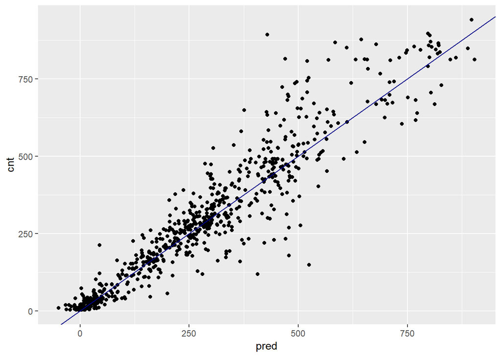

```r
# rodando o xgboost
bike_model_xgb <- xgboost(data = as.matrix(bikesJuly.treat), # treinando os dados da matrix
                   label = bikesJuly$cnt, # coluna com a variável dependente
                   nrounds = 87, # número de árvores que serão contruídas
                   objective = "reg:linear",
                   eta = 0.3,
                   depth = 6,
                   verbose = 0)

# fazendo previsões
bikesAugust$pred <- predict(bike_model_xgb, as.matrix(bikesAugust.treat))

# visualizando previsões X dados de aluguel de bicicletas atuais
ggplot(bikesAugust, aes(x = pred, y = cnt)) +
  geom_point() +
  geom_abline(color = "darkblue")
```

O gráfico de dispersão parecia muito bom, mas você notou que o modelo fez algumas previsões negativas? A seguir vou comparar o RMSE deste modelo com os modelos de bicicletas anteriores que você construiu.

#### 8.3.3) Avaliando o modelo de xgboost para aluguel de bicicletas

```r
# calculando o RMSE
bikesAugust %>%
  mutate(residuals = cnt - pred) %>%
  summarize(rmse = sqrt(mean(residuals^2)))
```

```
##       rmse
## 1 76.59275
```

Mesmo que esse aumento de gradiente tenha feito algumas previsões negativas, no geral ele gera erros menores do que os dois modelos anteriores. Talvez arredondar previsões negativas até zero seja uma troca razoável.

#### 8.3.4) Visualizando o modelo de xgboost para aluguel de bicicletas

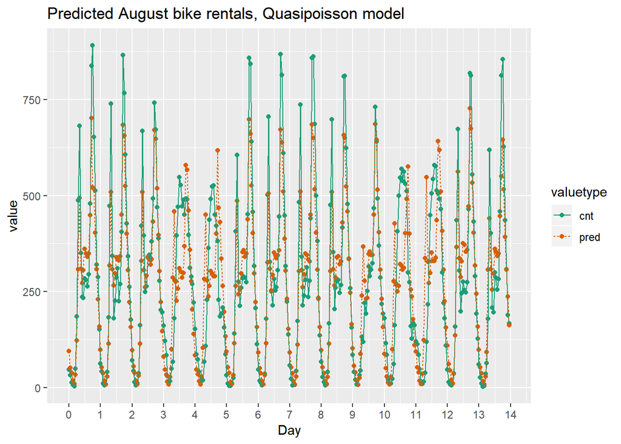

```r
# visualizando as previsões utilizando quasipoisson
quasipoisson_plot
```

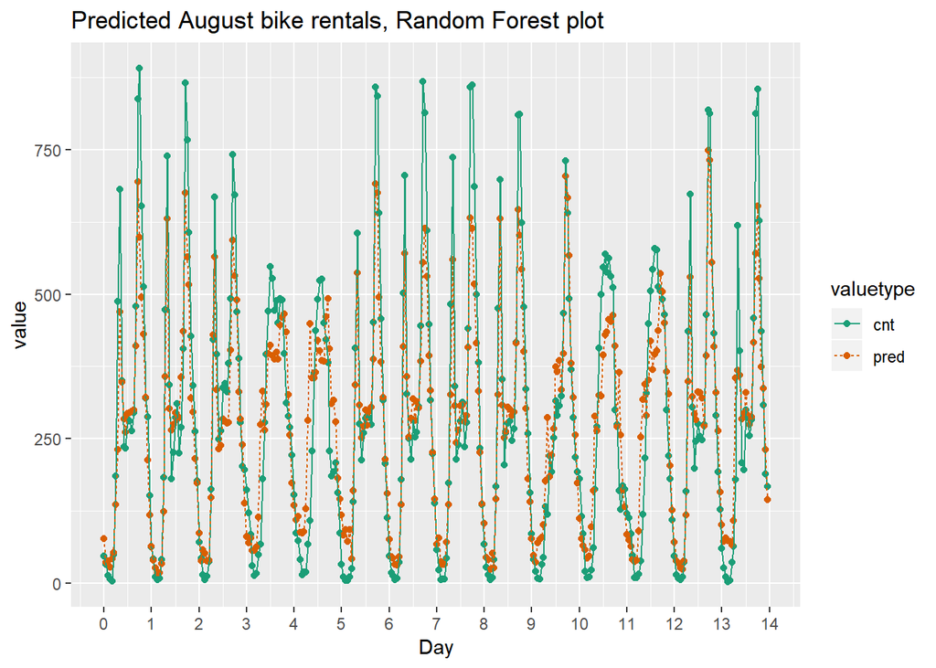

```r
# visualizando as previsões utilizando random forest
randomforest_plot
```

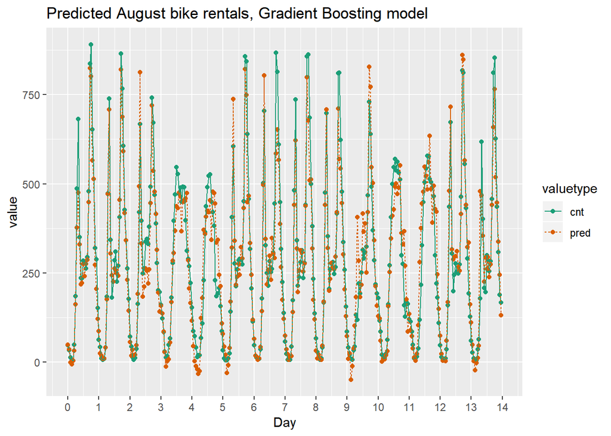

```r
# visualizando as previsões utilizando xgboost
bikesAugust %>%
  mutate(instant = (instant - min(instant))/24) %>%  # configurando oinício para o dia 0, convertendo unidades em dias
  gather(key = valuetype, value = value, cnt, pred) %>%
  filter(instant < 14) %>% # primeiras duas semanas
  ggplot(aes(x = instant, y = value, color = valuetype, linetype = valuetype)) +
  geom_point() +
  geom_line() +
  scale_x_continuous("Day", breaks = 0:14, labels = 0:14) +
  scale_color_brewer(palette = "Dark2") +
  ggtitle("Predicted August bike rentals, Gradient Boosting model")
```

Ótimo! Podemos perceber nas previsões utilizando o xgboost que houve um aumento na precisão da previsão, o xgboost captura variações de aluguel em função da hora do dia e outros fatores melhor que os modelos anteriores!